# Efficacy in Financial Rulemaking

```r
options(scipen=999)

# source(here::here("code", "setup.R"))

# defaults for plots
library(ggplot2); theme_set(theme_minimal());
options(
  ggplot2.continuous.color = "viridis",
  ggplot2.continuous.fill = "viridis"
)
scale_color_discrete <- function(...){
  scale_color_viridis_d(..., direction = -1,
                        begin = 0, end = .6, option = "viridis")}
scale_fill_discrete <- function(...){
  scale_fill_viridis_d(..., direction = -1,
                       begin = 0, end = .6, option = "viridis")}

scale_color_continuous <- function(...){
  scale_color_viridis_c(..., direction = -1,
                        option = "viridis")}
scale_fill_continuous <- function(...){
  scale_fill_viridis_c(..., direction = -1,
                       option = "viridis")}

# Table formatting
library(kableExtra)
kablebox <- . %>%
  slice_head(n = 300) %>%
  knitr::kable() %>%
  kable_styling() %>%
  scroll_box(height = "400px")
```

# Data

The root for this script is `finreg`. Most of the data are in `finreg/data` (some in a subfolder `merged_resources`). Others are up one level in `FINREGRULEMAKE2/Data`. This can and should be streamlined significantly.

## Sophistication

File: `Data/Dictionary_Terms.RData` contains 6 objects (3 sets of measures for both comments and attachments)

1. Dictionary counts of technical terms used in comments and attachments

Objects: `technical_terms_comments` and `technical_terms_attachment`

Variables:

- `doc_id` - the comment_url or attachment_url in the comments and attachments files in master.sqlite
- `uk_law` - UK law terms - this is in the file as I was curious how many of the terms would be in a UK law dictionary.
- `banking` - US banking terms in Merriam Webster’s banking dictionary
- `us_law` - US law terms terms in Merriam Webster’s US law dictionary. We didn’t use Black’s law dictionary because it’s incomplete as shown in the beginning of the `dictionary_and_bluebook.R` file
- `overlap` - terms in both banking and us_law
- `dictionary_term`s - banking + us_law - overlap
- `Comment` - 1 if from the comments file in Master, 0 if from attachments
2. Tables and Figures
- Counts of Tables and Figures. Looks at the maximum number of tables, with large jumps excluded. For example, a document with table 1, 2, 3 and 99 would treat 99 as an error and say there were 3 tables. This mostly comes from bad OCRing or documents that have footnotes in between the word “table” and the table number.

Objects: `Tables_and_Figures_attachments` and `Tables_and_Figures_comments`

Variables:

- `comment_url` - the comment_url or attachment_url in the comments and attachments files in master.sqlite
- `Figures` - counts of figures
- `Tables`- counts of tables
- `Comment` - 1 if from comments, 0 if from attachments
- `Visualizations` - sum of figures + tables
3. Bluebook

A file that has counts of citations to US code, Supreme Court cases, appellate and district court cases, the code of federal regulations, and the federal register

Objects: `bluebok_comments` and `bluebook_attachments`

Variables:

- `Comment` - 1 if from comments, 0 if from attachments
- `comment_url` - the comment_url or attachment_url in the comments and attachments files in master.sqlite
- `US_Code` - counts of US code citations
- `Supreme_Court_Cases` - counts of Supreme Court cases
- `Appeals_and_District_Court_Cases` - counts of citations to Appeals and district court cases
- `Code_of_Federal_Regulations` - counts of citations to CFR
- `Federal_Register_Total` - counts of citations to federal register
- `Total_Legal_Citations` - sum of above except comment dummy

```r
# sophistication
load(here("data", "Dictionary_Terms.Rdata")  %>% str_remove("finreg")  )

# drop duplicates
technical_terms_comments %<>%
  distinct()

technical_terms_attachments %<>%
  distinct()

bluebook_comments %<>%
  distinct()

bluebook_attachments %<>%
  distinct()
```

```r
# summarize and merge term counts from comment text boxes and attachments
# max <- . %>% base::max(na.rm = TRUE)


# sum by comment url
#FIXME, why are these not unique!
bluebook_c <- bluebook_comments %>%
  drop_na(Total_Legal_Citations) %>%
  group_by(comment_url) %>%
  dplyr::select(-comment) %>%
  summarise_all(base::max)

# whereas these should not be uniqe to comment url
bluebook_a <- bluebook_attachments %>%
  drop_na(Total_Legal_Citations) %>%
  group_by(comment_url) %>%
  dplyr::select(-comment) %>%
  summarise_all(base::max)

# join both and max again
bluebook <- full_join(bluebook_a,
                      bluebook_c) %>%
  group_by(comment_url) %>%
  summarise_all(base::max)

# # check for unique comment_url
# bluebook %>% count(comment_url, sort = T)

# sum by comment url
#FIXME, why are these not unique!?
technical_terms_c <- technical_terms_comments %>%
  drop_na(dictionary_terms) %>%
  group_by(comment_url) %>%
  dplyr::select(-comment) %>%
  summarise_all(base::max)

# whereas these should not be uniqe to comment url
technical_terms_a <- technical_terms_attachments %>%
  drop_na(dictionary_terms) %>%
  group_by(comment_url) %>%
  dplyr::select(-comment) %>%
  summarise_all(base::max)

# join both and sum again
technical_terms <- full_join(technical_terms_a,
                             technical_terms_c) %>%
  group_by(comment_url) %>%
  summarise_all(base::max)

# # check for unique comment_url
# technical_terms %>% count(comment_url, sort = T)

full_join(technical_terms, bluebook) %>% kablebox()
```

| comment_url | attachment_url | uk_law | banking | us_law | overlap | dictionary_terms | US_Code | Supreme_Court_Cases | Appeals_and_District_Court_Cases | Code_of_Federal_Regulations | Federal_Register_Total | Total_Legal_Citations |
| --- | --- | --- | --- | --- | --- | --- | --- | --- | --- | --- | --- | --- |
| https://comments.cftc.gov/PublicComments/ViewComment.aspx?id=10 | NA | 20 | 62 | 101 | 28 | 135 | NA | NA | NA | NA | NA | NA |
| https://comments.cftc.gov/PublicComments/ViewComment.aspx?id=100 | NA | 5 | 22 | 35 | 11 | 46 | NA | NA | NA | NA | NA | NA |
| https://comments.cftc.gov/PublicComments/ViewComment.aspx?id=1000 | NA | 4 | 7 | 12 | 2 | 17 | NA | NA | NA | NA | NA | NA |
| https://comments.cftc.gov/PublicComments/ViewComment.aspx?id=1001 | NA | 1 | 5 | 11 | 4 | 12 | NA | NA | NA | NA | NA | NA |
| https://comments.cftc.gov/PublicComments/ViewComment.aspx?id=1002 | NA | 8 | 22 | 42 | 11 | 53 | NA | NA | NA | NA | NA | NA |
| https://comments.cftc.gov/PublicComments/ViewComment.aspx?id=1003 | NA | 22 | 29 | 75 | 18 | 86 | NA | NA | NA | NA | NA | NA |
| https://comments.cftc.gov/PublicComments/ViewComment.aspx?id=1004 | NA | 2 | 12 | 22 | 5 | 29 | NA | NA | NA | NA | NA | NA |
| https://comments.cftc.gov/PublicComments/ViewComment.aspx?id=1005 | NA | 31 | 56 | 92 | 39 | 109 | NA | NA | NA | NA | NA | NA |
| https://comments.cftc.gov/PublicComments/ViewComment.aspx?id=1006 | NA | 2 | 14 | 14 | 7 | 21 | NA | NA | NA | NA | NA | NA |
| https://comments.cftc.gov/PublicComments/ViewComment.aspx?id=1007 | NA | 9 | 13 | 33 | 9 | 37 | NA | NA | NA | NA | NA | NA |
| https://comments.cftc.gov/PublicComments/ViewComment.aspx?id=1008 | NA | 3 | 8 | 22 | 5 | 25 | NA | NA | NA | NA | NA | NA |
| https://comments.cftc.gov/PublicComments/ViewComment.aspx?id=1009 | NA | 7 | 19 | 47 | 8 | 58 | NA | NA | NA | NA | NA | NA |
| https://comments.cftc.gov/PublicComments/ViewComment.aspx?id=101 | NA | 12 | 18 | 59 | 8 | 69 | NA | NA | NA | NA | NA | NA |
| https://comments.cftc.gov/PublicComments/ViewComment.aspx?id=1010 | NA | 1 | 7 | 9 | 2 | 14 | NA | NA | NA | NA | NA | NA |
| https://comments.cftc.gov/PublicComments/ViewComment.aspx?id=1011 | NA | 20 | 33 | 94 | 18 | 109 | NA | NA | NA | NA | NA | NA |
| https://comments.cftc.gov/PublicComments/ViewComment.aspx?id=1012 | NA | 1 | 6 | 13 | 2 | 17 | NA | NA | NA | NA | NA | NA |
| https://comments.cftc.gov/PublicComments/ViewComment.aspx?id=1013 | NA | 26 | 40 | 75 | 21 | 94 | NA | NA | NA | NA | NA | NA |
| https://comments.cftc.gov/PublicComments/ViewComment.aspx?id=1014 | NA | 7 | 15 | 31 | 9 | 37 | NA | NA | NA | NA | NA | NA |
| https://comments.cftc.gov/PublicComments/ViewComment.aspx?id=1015 | NA | 7 | 17 | 29 | 11 | 35 | NA | NA | NA | NA | NA | NA |
| https://comments.cftc.gov/PublicComments/ViewComment.aspx?id=1016 | NA | 27 | 61 | 113 | 34 | 140 | NA | NA | NA | NA | NA | NA |
| https://comments.cftc.gov/PublicComments/ViewComment.aspx?id=1017 | NA | 1 | 10 | 18 | 6 | 22 | NA | NA | NA | NA | NA | NA |
| https://comments.cftc.gov/PublicComments/ViewComment.aspx?id=1018 | NA | 3 | 7 | 14 | 5 | 16 | NA | NA | NA | NA | NA | NA |
| https://comments.cftc.gov/PublicComments/ViewComment.aspx?id=1019 | NA | 3 | 10 | 17 | 6 | 21 | NA | NA | NA | NA | NA | NA |
| https://comments.cftc.gov/PublicComments/ViewComment.aspx?id=102 | NA | 24 | 34 | 83 | 17 | 100 | NA | NA | NA | NA | NA | NA |
| https://comments.cftc.gov/PublicComments/ViewComment.aspx?id=1020 | NA | 7 | 17 | 28 | 12 | 33 | NA | NA | NA | NA | NA | NA |
| https://comments.cftc.gov/PublicComments/ViewComment.aspx?id=1021 | NA | 0 | 4 | 5 | 1 | 8 | NA | NA | NA | NA | NA | NA |
| https://comments.cftc.gov/PublicComments/ViewComment.aspx?id=1022 | NA | 2 | 5 | 17 | 3 | 19 | NA | NA | NA | NA | NA | NA |
| https://comments.cftc.gov/PublicComments/ViewComment.aspx?id=1023 | NA | 9 | 14 | 32 | 8 | 38 | NA | NA | NA | NA | NA | NA |
| https://comments.cftc.gov/PublicComments/ViewComment.aspx?id=1024 | NA | 6 | 8 | 23 | 5 | 26 | NA | NA | NA | NA | NA | NA |
| https://comments.cftc.gov/PublicComments/ViewComment.aspx?id=1025 | NA | 8 | 13 | 41 | 8 | 46 | NA | NA | NA | NA | NA | NA |

[output cut: 270 more lines]

```r
# check that they are the same
# full_join(bluebook, technical_terms)
```

## Assets

- see https://judgelord.github.io/finreg/participation

```r
load(here::here("data", "commenter_assets.Rdata"))

d <- commenter_assets

#FIXME MOVE TO TOP
d$comment_url %<>% str_replace("document\\?D=", "comment/")


d %>% arrange(assets) %>%
  dplyr::select(org_name, assets, revenue, comment_url) %>% kablebox()
```

| org_name | assets | revenue | comment_url |
| --- | --- | --- | --- |
| sc independent living council | -3896 | 46840 | https://www.regulations.gov/comment/CFPB-2016-0025-208045 |
| super science | -3607 | 72660 | https://comments.cftc.gov/PublicComments/ViewComment.aspx?id=34131 |
| christ apostolic church victory center | -2525 | 1375 | https://www.regulations.gov/comment/CFPB-2016-0025-21204 |
| odessa elderly housing | -541 | 0 | https://www.sec.gov/comments/s7-45-10/s74510-700.pdf |
| omni life community health partners | -38 | 4200 | https://www.regulations.gov/comment/CFPB-2016-0020-3104 |
| omni life community health partners | -38 | 4200 | https://www.regulations.gov/comment/CFPB-2011-0008-0327 |
| omni life community health partners | -38 | 4200 | https://www.regulations.gov/comment/CFPB-2013-0010-0012 |
| omni life community health partners | -38 | 4200 | https://www.regulations.gov/comment/CFPB-2013-0013-0080 |
| omni life community health partners | -38 | 4200 | https://www.regulations.gov/comment/CFPB-2011-0008-0023 |
| omni life community health partners | -38 | 4200 | https://www.federalreserve.gov/SECRS/2011/January/20110121/R-1404/R-1404_011911_61789_560982947127_1.pdf |
| omni life community health partners | -38 | 4200 | https://www.federalreserve.gov/SECRS/2011/July/20110707/R-1417/R-1417_070611_81724_516054735780_1.pdf |
| omni life community health partners | -38 | 4200 | https://www.federalreserve.gov/SECRS/2010/December/20101228/R-1394/R-1394_121710_57462_465475515251_1.pdf |
| great plains region homeownership opportunities women | 0 | 0 | https://www.regulations.gov/comment/CFPB-2016-0025-135256 |
| south baltimore pigeon fanciers social club | 0 | 15799 | https://www.regulations.gov/comment/CFPB-2014-0033-0041 |
| joint trade committee painting decorating industry | 0 | 0 | https://www.regulations.gov/comment/CFPB-2012-0028-0495 |
| vested interest community services | 0 | 49409 | https://www.regulations.gov/comment/CFPB-2012-0028-2154 |
| inland empire legal association women | 0 | 0 | https://www.sec.gov/comments/s7-27-10/s72710-49.htm |
| capital city organizational development network | 0 | 10251 | https://www.sec.gov/comments/s7-07-13/s70713-381.pdf |
| credit union department state texas | 0 | 0 | https://www.federalreserve.gov/SECRS/2011/February/20110223/R-1404/R-1404_022211_67247_584261267257_1.pdf |
| amish country central illinois cvb | 0 | 38371 | https://www.federalreserve.gov/SECRS/2011/March/20110322/R-1404/R-1404_032111_69219_590328492738_1.pdf |
| inland empire legal association women | 0 | 0 | https://comments.cftc.gov/PublicComments/ViewComment.aspx?id=26451 |
| colorado assoc animal control officers | 0 | 0 | https://comments.cftc.gov/PublicComments/ViewComment.aspx?id=33843 |
| consumers research | 1 | 0 | https://www.regulations.gov/comment/CFPB-2019-0022-9580 |
| parkers grove baptist church | 1 | 36933 | https://www.regulations.gov/comment/CFPB-2016-0025-144896 |
| resurrection baptist church community development | 1 | 1 | https://www.regulations.gov/comment/CFPB-2016-0025-144893 |
| american legion auxiliary alton indiana unit no 1388 8th district | 1 | 3773 | https://www.regulations.gov/comment/CFPB-2016-0025-200391 |
| cornerstone home gardens | 1 | 3350 | https://www.regulations.gov/comment/CFPB-2013-0002-0315 |
| ppep first american resources services | 1 | 1 | https://www.regulations.gov/comment/CFPB-2013-0002-0386 |
| aba securities association | 1 | 440000 | https://www.sec.gov/comments/s7-16-11/s71611-38.pdf |
| aba securities association | 1 | 440000 | https://www.sec.gov/comments/s7-41-11/s74111-254.pdf |

[output cut: 270 more lines]

```r
d %>% arrange(marketcap2) %>%
  dplyr::select(org_name, marketcap2, comment_url) %>% kablebox()
```

| org_name | marketcap2 | comment_url |
| --- | --- | --- |
| pulse network | 72054 | https://www.federalreserve.gov/SECRS/2011/March/20110303/R-1404/R-1404_022211_67837_571547531696_1.pdf |
| capital financial | 124100 | https://www.regulations.gov/comment/CFPB-2012-0037-0709 |
| capital financial | 124100 | https://www.regulations.gov/comment/CFPB-2013-0002-0819 |
| sino green land | 2210000 | https://www.regulations.gov/comment/CFPB-2011-0008-1460 |
| international monetary systems ltd wi | 3218000 | https://www.sec.gov/comments/s7-42-10/s74210-72.pdf |
| princeton capital | 21687000 | https://www.regulations.gov/comment/CFPB-2012-0028-0098 |
| leading edge materials | 26453000 | https://www.federalreserve.gov/SECRS/2010/November/20101129/R-1394/R-1394_112410_55015_317409371219_1.pdf |
| diversified mortgage workout | 26570000 | https://www.regulations.gov/comment/CFPB-2012-0037-0396 |
| diversified mortgage workout | 26570000 | https://www.regulations.gov/comment/CFPB-2012-0037-0588 |
| diversified mortgage workout | 26570000 | https://www.regulations.gov/comment/CFPB-2012-0037-0681 |
| diversified mortgage workout | 26570000 | https://www.regulations.gov/comment/CFPB-2012-0037-0610 |
| diversified mortgage workout | 26570000 | https://www.regulations.gov/comment/CFPB-2012-0037-0688 |
| diversified mortgage workout | 26570000 | https://www.regulations.gov/comment/CFPB-2012-0037-0661 |
| diversified mortgage workout | 26570000 | https://www.regulations.gov/comment/CFPB-2012-0037-0625 |
| diversified mortgage workout | 26570000 | https://www.regulations.gov/comment/CFPB-2012-0037-0642 |
| diversified mortgage workout | 26570000 | https://www.regulations.gov/comment/CFPB-2012-0037-0693 |
| diversified mortgage workout | 26570000 | https://www.regulations.gov/comment/CFPB-2012-0037-0649 |
| diversified mortgage workout | 26570000 | https://www.regulations.gov/comment/CFPB-2012-0037-0581 |
| diversified mortgage workout | 26570000 | https://www.regulations.gov/comment/CFPB-2012-0037-0647 |
| diversified mortgage workout | 26570000 | https://www.regulations.gov/comment/CFPB-2012-0037-0616 |
| diversified mortgage workout | 26570000 | https://www.regulations.gov/comment/CFPB-2012-0037-0617 |
| diversified mortgage workout | 26570000 | https://www.regulations.gov/comment/CFPB-2012-0028-2039 |
| diversified mortgage workout | 26570000 | https://www.regulations.gov/comment/CFPB-2013-0018-0230 |
| innovative medical services | 33145000 | https://www.regulations.gov/comment/CFPB-2013-0002-0463 |
| innovative medical services | 33145000 | https://www.regulations.gov/comment/CFPB-2013-0002-0447 |
| innovative medical services | 33145000 | https://www.regulations.gov/comment/CFPB-2013-0002-0719 |
| innovative medical services | 33145000 | https://www.regulations.gov/comment/CFPB-2013-0002-0519 |
| impac mortgage | 38186000 | https://www.regulations.gov/comment/CFPB-2012-0028-1471 |
| impac mortgage | 38186000 | https://www.regulations.gov/comment/CFPB-2013-0002-0095 |
| anchor funding services | 49177000 | https://www.regulations.gov/comment/CFPB-2013-0002-0227 |

[output cut: 270 more lines]

```r
d %>% arrange(-MeanContribAmount) %>%
  dplyr::select(org_name, MeanContribAmount, comment_url) %>% kablebox()
```

| org_name | MeanContribAmount | comment_url |
| --- | --- | --- |
| us chamber commerce | 85367724 | https://www.regulations.gov/comment/CFPB-2014-0024-0026 |
| us chamber commerce | 85367724 | https://www.regulations.gov/comment/CFPB-2013-0033-0329 |
| us chamber commerce | 85367724 | https://www.regulations.gov/comment/CFPB-2014-0010-0103 |
| us chamber commerce | 85367724 | https://www.regulations.gov/comment/CFPB-2011-0005-0005 |
| us chamber commerce | 85367724 | https://www.regulations.gov/comment/CFPB-2012-0010-0026 |
| us chamber commerce | 85367724 | https://www.regulations.gov/comment/CFPB-2012-0005-0077 |
| us chamber commerce | 85367724 | https://www.regulations.gov/comment/CFPB-2011-0002-0470 |
| us chamber commerce | 85367724 | https://www.sec.gov/comments/s7-08-13/s70813-11.pdf |
| us chamber commerce | 85367724 | https://www.sec.gov/comments/s7-41-11/s74111-676.pdf |
| us chamber commerce | 85367724 | https://www.sec.gov/comments/s7-41-11/s74111-674.pdf |
| us chamber commerce | 85367724 | https://www.sec.gov/comments/s7-41-11/s74111-680.pdf |
| us chamber commerce | 85367724 | https://www.sec.gov/comments/s7-41-11/s74111-642.pdf |
| us chamber commerce | 85367724 | https://www.sec.gov/comments/s7-41-11/s74111-614.pdf |
| us chamber commerce | 85367724 | https://www.sec.gov/comments/s7-41-11/s74111-611.pdf |
| us chamber commerce | 85367724 | https://www.sec.gov/comments/s7-03-13/s70313-380.pdf |
| us chamber commerce | 85367724 | https://www.sec.gov/comments/s7-41-11/s74111-597.pdf |
| us chamber commerce | 85367724 | https://www.sec.gov/comments/s7-05-11/s70511-22.pdf |
| us chamber commerce | 85367724 | https://www.sec.gov/comments/s7-03-13/s70313-344.pdf |
| us chamber commerce | 85367724 | https://www.sec.gov/comments/s7-03-13/s70313-234.pdf |
| us chamber commerce | 85367724 | https://www.sec.gov/comments/s7-08-12/s70812-116.pdf |
| us chamber commerce | 85367724 | https://www.sec.gov/comments/s7-03-13/s70313-43.pdf |
| us chamber commerce | 85367724 | https://www.sec.gov/comments/s7-03-13/s70313-39.pdf |
| us chamber commerce | 85367724 | https://www.sec.gov/comments/s7-41-11/s74111-73.pdf |
| us chamber commerce | 85367724 | https://www.sec.gov/comments/s7-33-10/s73310-145.pdf |
| us chamber commerce | 85367724 | https://www.sec.gov/comments/s7-41-11/s74111-29.pdf |
| us chamber commerce | 85367724 | https://www.sec.gov/comments/s7-41-11/s74111-21.pdf |
| us chamber commerce | 85367724 | https://www.sec.gov/comments/s7-33-10/s73310-189.pdf |
| us chamber commerce | 85367724 | https://www.sec.gov/comments/s7-14-11/s71411-565.pdf |
| us chamber commerce | 85367724 | https://www.sec.gov/comments/s7-31-10/s73110-47.pdf |
| us chamber commerce | 85367724 | https://www.sec.gov/comments/s7-12-11/s71211-752.pdf |

[output cut: 270 more lines]

## Efficacy

File: `Data/attachment_efficacy_w_docket.csv.`

Variables:

- `efficacy` = `cumulative_sequence_length_over_10`

Other efficacy measures that we are not using:

```r
# efficacy
efficacy_raw <- read_csv( here::here("data", "new_attachment_efficacy_w_docket.csv")  %>% str_remove("finreg")  )

names(efficacy_raw) %>% kable()
```

| x |
| --- |
| comment_url |
| attachment_url |
| comment |
| url |
| Types |
| Tokens |
| Sentences |
| Comments_Until |
| docket_id |
| fr_document_id_proposed |
| fr_document_id_final |
| iteration |
| number_of_other_sequences_over_10 |
| number_of_other_sequences_over_25 |
| number_of_other_sequences_over_50 |
| number_of_other_sequences_over_100 |
| cumulative_sequence_length_over_10 |
| cumulative_sequence_length_over_25 |
| cumulative_sequence_length_over_50 |
| cumulative_sequence_length_over_100 |
| longest_sequence_length |
| longest_repeated_text |

```r
# inspect
# efficacy_raw %>% distinct() %>% dplyr::select(attachment_url, fr_document_id_final) %>% add_count(attachment_url) %>% arrange(-n) %>%   kablebox()

# # look for non-numeric values other than headers
# efficacy_raw %>%
#   filter(!is.na(cumulative_sequence_length_over_10),
#          comment_url != "comment_url") %>%
#   mutate(efficacy = cumulative_sequence_length_over_10 %>% as.numeric() ) %>%
#   filter(is.na(efficacy)) %>%
#   dplyr::select(comment_url, cumulative_sequence_length_over_10)

# select needed vars. url is comment url (even for attachments)
efficacy <- efficacy_raw %>%
  # make comment url
  mutate(comment_url2 = attachment_url %>%
           str_replace("https://downloads.regulations.gov/",
                       "https://www.regulations.gov/comment/" ) %>%
           str_remove("/attachment_.*"),
         comment_url = coalesce(comment_url, comment_url2),
         efficacy = cumulative_sequence_length_over_10 %>% as.numeric()
         ) %>%
  dplyr::select(comment_url,
         efficacy) %>%
  distinct()

# check for OCC comments (missing as of May 2022)
# efficacy %>% filter(str_detect(comment_url, "OCC"))

# check for CFPB comments (not missing, but failing to merge with d on URL?)
# efficacy %>% filter(str_detect(comment_url, "CFPB"))



max <- . %>% base::max(na.rm = TRUE)

efficacy %>% drop_na(efficacy) %>% nrow()
```

```
## [1] 57720
```

```r
efficacy %<>% drop_na(efficacy)


# take max
efficacy %<>%
  group_by(comment_url) %>%
  summarise_all(base::max)

efficacy %>% arrange(-efficacy) %>% kablebox()
```

| comment_url | efficacy |
| --- | --- |
| https://comments.cftc.gov/Handlers/PdfHandler.ashx?id=23750 | 62158 |
| https://www.regulations.gov/comment/CFPB-2012-0029-0054 | 46512 |
| https://www.sec.gov/comments/s7-33-10/s73310-110.pdf | 10131 |
| https://www.sec.gov/comments/s7-33-10/s73310-35.pdf | 10131 |
| https://comments.cftc.gov/Handlers/PdfHandler.ashx?id=24275 | 7593 |
| https://comments.cftc.gov/Handlers/PdfHandler.ashx?id=24205 | 7411 |
| https://www.sec.gov/comments/s7-41-11/s74111-230.pdf | 7312 |
| https://www.sec.gov/comments/s7-25-11/s72511-55.pdf | 5809 |
| https://www.sec.gov/comments/s7-18-11/s71811-32.pdf | 5563 |
| https://comments.cftc.gov/Handlers/PdfHandler.ashx?id=25016 | 4965 |
| https://www.sec.gov/comments/s7-33-10/s73310-265.pdf | 4886 |
| https://comments.cftc.gov/Handlers/PdfHandler.ashx?id=23733 | 4710 |
| https://www.sec.gov/comments/s7-35-10/s73510-12.pdf | 4687 |
| https://www.federalreserve.gov/SECRS/2012/March/20120305/R-1432/R-1432_021312_104404_346801484756_1.pdf | 4482 |
| https://comments.cftc.gov/Handlers/PdfHandler.ashx?id=23871 | 4445 |
| https://comments.cftc.gov/Handlers/PdfHandler.ashx?id=24090 | 4445 |
| https://www.sec.gov/comments/s7-41-11/s74111-207.pdf | 4409 |
| https://www.sec.gov/comments/s7-08-10/s70810-247.pdf | 4204 |
| https://www.regulations.gov/comment/CFPB-2016-0025-154512 | 3794 |
| https://www.regulations.gov/comment/CFPB-2016-0025-185182 | 3794 |
| https://www.federalreserve.gov/SECRS/2012/December/20121206/R-1442/R-1442_102212_110014_386243203248_1.pdf | 3653 |
| https://comments.cftc.gov/Handlers/PdfHandler.ashx?id=25113 | 3402 |
| https://www.regulations.gov/comment/CFPB-2014-0033-0119 | 3366 |
| https://www.regulations.gov/comment/CFPB-2014-0033-0136 | 3202 |
| https://www.sec.gov/comments/s7-45-10/s74510-587.pdf | 3083 |
| https://www.regulations.gov/comment/CFPB-2016-0025-109324 | 3000 |
| https://comments.cftc.gov/Handlers/PdfHandler.ashx?id=23870 | 2656 |
| https://comments.cftc.gov/Handlers/PdfHandler.ashx?id=24092 | 2656 |
| https://www.sec.gov/comments/s7-41-11/s74111-210.pdf | 2597 |
| https://www.federalreserve.gov/SECRS/2012/March/20120305/R-1432/R-1432_021312_104703_532361297436_1.pdf | 2587 |

[output cut: 270 more lines]

```r
d$comment_url %in% efficacy$comment_url %>% sum
```

```
## [1] 5713
```

```r
efficacy$comment_url %in% d$comment_url %>% sum
```

```
## [1] 5713
```

```r
#efficacy %>% filter(str_detect(comment_url, "CFPB")) %>%  kablebox()

d  %>% left_join(efficacy) %>% drop_na(efficacy) %>% count(Agency)
```

```
## # A tibble: 4 × 2
##   Agency     n
##   <chr>  <int>
## 1 CFPB    3159
## 2 FRS     1044
## 3 NCUA      11
## 4 SEC     1499
```

```r
d  %<>% left_join(efficacy)
```

```r
# check number of NAs
bluebook_comments %>%
  summarise_all(is.na) %>%
  summarise_all(sum)

# multiple per url?
bluebook_comments %>%  count(comment_url, sort = T)

bluebook_attachments %>%  count(comment_url, sort = T)

# example
bluebook_attachments %>% filter(comment_url == "https://www.regulations.gov/comment/OCC-2011-0008-0126") %>% kablebox()

bluebook_comments %>% filter(comment_url == "https://www.regulations.gov/comment/OCC-2011-0008-0126") %>% kablebox()

technical_terms_comments %>% count(comment_url, sort = T)

technical_terms_attachments %>% count(comment_url, sort = T)
```

### Join sophistication and asset data

```r
# Join
d %<>%
  left_join(bluebook %>% dplyr::select(comment_url, Total_Legal_Citations)) %>%
  left_join(technical_terms %>% dplyr::select(comment_url, dictionary_terms))

d %>%
  dplyr::select(comment_url, org_name, Total_Legal_Citations, dictionary_terms) %>%
  filter(!is.na(dictionary_terms)) %>%
  kablebox()
```

| comment_url | org_name | Total_Legal_Citations | dictionary_terms |
| --- | --- | --- | --- |
| https://www.regulations.gov/comment/CFPB-2016-0025-211929 | united states senate | 0 | 0 |
| https://www.regulations.gov/comment/CFPB-2016-0038-1645 | keller williams realty | 0 | 0 |
| https://www.regulations.gov/comment/CFPB-2016-0038-1637 | keller williams realty | 0 | 0 |
| https://www.regulations.gov/comment/CFPB-2016-0038-1643 | associates realty | 0 | 0 |
| https://www.regulations.gov/comment/CFPB-2016-0038-1642 |  | 0 | 0 |
| https://www.regulations.gov/comment/CFPB-2016-0038-1635 | ebby halliday realtors | 0 | 0 |
| https://www.regulations.gov/comment/CFPB-2016-0038-1641 | town country bank missouri | 0 | 0 |
| https://www.regulations.gov/comment/CFPB-2017-0021-0037 | california credit union league | 0 | 0 |
| https://www.regulations.gov/comment/CFPB-2016-0025-211699 |  | 0 | 0 |
| https://www.regulations.gov/comment/CFPB-2016-0025-211694 |  | 0 | 0 |
| https://www.regulations.gov/comment/CFPB-2016-0025-211685 | national call center | 0 | 0 |
| https://www.regulations.gov/comment/CFPB-2016-0025-211656 |  | 0 | 0 |
| https://www.regulations.gov/comment/CFPB-2016-0025-211710 |  | 0 | 0 |
| https://www.regulations.gov/comment/CFPB-2016-0025-211675 | national call center | 0 | 0 |
| https://www.regulations.gov/comment/CFPB-2016-0025-211700 |  | 0 | 0 |
| https://www.regulations.gov/comment/CFPB-2016-0025-211706 |  | 0 | 0 |
| https://www.regulations.gov/comment/CFPB-2016-0025-211697 |  | 0 | 0 |
| https://www.regulations.gov/comment/CFPB-2016-0025-211676 |  | 0 | 0 |
| https://www.regulations.gov/comment/CFPB-2016-0025-211674 | national call center | 0 | 0 |
| https://www.regulations.gov/comment/CFPB-2016-0025-211687 |  | 0 | 0 |
| https://www.regulations.gov/comment/CFPB-2016-0025-211852 |  | 0 | 0 |
| https://www.regulations.gov/comment/CFPB-2016-0025-211845 |  | 0 | 0 |
| https://www.regulations.gov/comment/CFPB-2016-0025-211840 |  | 0 | 0 |
| https://www.regulations.gov/comment/CFPB-2016-0025-211864 |  | 0 | 0 |
| https://www.regulations.gov/comment/CFPB-2016-0025-211854 |  | 0 | 0 |
| https://www.regulations.gov/comment/CFPB-2016-0025-211763 |  | 0 | 0 |
| https://www.regulations.gov/comment/CFPB-2016-0025-211821 | texas hereford association | 0 | 0 |
| https://www.regulations.gov/comment/CFPB-2016-0025-211765 |  | 0 | 0 |
| https://www.regulations.gov/comment/CFPB-2016-0025-211751 |  | 0 | 0 |
| https://www.regulations.gov/comment/CFPB-2016-0025-211770 |  | 0 | 0 |

[output cut: 270 more lines]

```r
# write out missing comment urls
d %>%
  filter(is.na(dictionary_terms)) %>% dplyr::select(comment_url) %>% write_csv(file = "dictionary_terms_missing.csv")

# FIXME Missing as of May 2022
# bluebook %>% filter(str_detect(comment_url, "CFPB-2019-0021-0406"))
# technical_terms %>% filter(str_detect(comment_url, "CFPB-2019-0021-0406"))
```

### Number of comments per agency

Technical terms measured for 27122 of 27601 comments.

```r
# matches
d %>%
  count(Agency) %>%
  left_join(
    d %>%
      filter(comment_url %in% technical_terms$comment_url) %>%
      count(Agency, name = "n with dictionary terms measured")
    )  %>%
  kablebox()
```

| Agency | n | n with dictionary terms measured |
| --- | --- | --- |
| CFPB | 14374 | 13954 |
| CFTC | 5341 | 5336 |
| FRS | 3869 | 3869 |
| NCUA | 84 | 30 |
| SEC | 3933 | 3933 |

# Plots

## Sophistication x assets

### Legal citations x assets

```r
# bluebook %>% count(is.na(Total_Legal_Citations))

# 400 from FDIC data, 400 from other data
b <- d %>% filter(!is.na(dictionary_terms))

b %>% dplyr::select(org_name, Total_Legal_Citations, org_resources, comment_url)  %>%
  drop_na(org_name, org_resources) %>%
  kablebox()
```

| org_name | Total_Legal_Citations | org_resources | comment_url |
| --- | --- | --- | --- |
| town country bank missouri | 0 | 26610 | https://www.regulations.gov/comment/CFPB-2016-0038-1641 |
| california credit union league | 0 | 17811333 | https://www.regulations.gov/comment/CFPB-2017-0021-0037 |
| texas hereford association | 0 | 88213 | https://www.regulations.gov/comment/CFPB-2016-0025-211821 |
| civil justice | 0 | 700211 | https://www.regulations.gov/comment/CFPB-2016-0025-211828 |
| bank forest | 0 | 165509 | https://www.regulations.gov/comment/CFPB-2016-0025-211822 |
| acf 2012 host committee | 0 | 25558 | https://www.regulations.gov/comment/CFPB-2016-0025-211877 |
| civil justice | 0 | 700211 | https://www.regulations.gov/comment/CFPB-2016-0025-211870 |
| bank forest | 0 | 165509 | https://www.regulations.gov/comment/CFPB-2016-0025-211876 |
| housing initiative partnership | 0 | 1320283 | https://www.regulations.gov/comment/CFPB-2016-0025-211873 |
| covering kids families indiana | 0 | 200003 | https://www.regulations.gov/comment/CFPB-2016-0025-211879 |
| germania credit union | 0 | 11242319 | https://www.regulations.gov/comment/CFPB-2016-0025-211911 |
| american escrow association | 0 | 203188 | https://www.regulations.gov/comment/CFPB-2017-0018-0016 |
| american pacific bank | 0 | 124355 | https://www.regulations.gov/comment/CFPB-2017-0018-0021 |
| iowa bankers association | 0 | 9939509 | https://www.regulations.gov/comment/CFPB-2017-0018-0023 |
| real estate services providers council | 0 | 653451 | https://www.regulations.gov/comment/CFPB-2017-0018-0022 |
| national association home builders united states | 0 | 105827166 | https://www.regulations.gov/comment/CFPB-2017-0018-0026 |
| american escrow association | 0 | 203188 | https://www.regulations.gov/comment/CFPB-2017-0018-0041 |
| texas mortgage bankers association | 0 | 1493337 | https://www.regulations.gov/comment/CFPB-2017-0018-0038 |
| ohio credit union league | 0 | 425742 | https://www.regulations.gov/comment/CFPB-2017-0018-0045 |
| independent community bankers america | 0 | 100476445 | https://www.regulations.gov/comment/CFPB-2017-0018-0031 |
| national consumer law center | 0 | 17440205 | https://www.regulations.gov/comment/CFPB-2017-0018-0049 |
| american bankers association | 0 | 129958383 | https://www.regulations.gov/comment/CFPB-2017-0018-0035 |
| national consumer law center | 0 | 17440205 | https://www.regulations.gov/comment/CFPB-2017-0018-0040 |
| american bankers association | 0 | 129958383 | https://www.regulations.gov/comment/CFPB-2017-0018-0039 |
| national association home builders united states | 0 | 105827166 | https://www.regulations.gov/comment/CFPB-2017-0018-0046 |
| national association realtors | 0 | 258251232 | https://www.regulations.gov/comment/CFPB-2017-0018-0037 |
| national consumer law center | 0 | 17440205 | https://www.regulations.gov/comment/CFPB-2017-0018-0050 |
| adventist community services north america | 0 | 2522436 | https://www.regulations.gov/comment/CFPB-2016-0025-211928 |
| reliance bank | 0 | 28637 | https://www.regulations.gov/comment/CFPB-2017-0021-0005 |
| iowa bankers association | 0 | 9939509 | https://www.regulations.gov/comment/CFPB-2017-0021-0007 |

[output cut: 270 more lines]

| org_name | Total_Legal_Citations | comment_url | docket_id | comment_docket_count | comment_agency | comment_org_name | comment_submitter_name | CIK_name | CreditUnions_name | FDIC_Institutions_name | FFIECInstitutions_name | SEC_Institutions_name | compustat_resources_name | nonprofits_resources_name | opensecrets_resources_jwVersion_name | best_match_name | best_match_score | best_match_type | FDIC_Institutions-bestMatch:ASSET | FDIC_Institutions-bestMatch:STNAME | CIK-bestMatch:marketcap | SEC_Institutions-bestMatch:Ticker | compustat_resources-bestMatch:marketcap | compustat_resources-bestMatch:naics | nonprofits_resources-bestMatch:assets | nonprofits_resources-bestMatch:revenue | nonprofits_resources-bestMatch:ein | opensecrets_resources_jwVersion-bestMatch:MeanContribAmountPerYearContributed | opensecrets_resources_jwVersion-bestMatch:TotalContribAmount | … |
| --- | --- | --- | --- | --- | --- | --- | --- | --- | --- | --- | --- | --- | --- | --- | --- | --- | --- | --- | --- | --- | --- | --- | --- | --- | --- | --- | --- | --- | --- | --- |
| advance financial | 273 | https://www.regulations.gov/comment/CFPB-2016-0025-3913 | CFPB-2016-0025 | 1 | CFPB | advance financial | mike hodges | NA | advance financial | NA | NA | NA | NA | NA | NA | advance financial | 1.0000000 | Credit Union | NA | NA | NA | NA | NA | NA | NA | NA | NA | NA | NA | … |
|  | 198 | https://www.federalreserve.gov/SECRS/2012/June/20120608/R-1438/R-1438_043012_107253_401117527948_1.pdf | R-1438 | 1 | FRS | federated investors | inc | NA | NA | NA | NA | NA | NA | NA | NA | federated investors | 1.0000000 | Compustat | NA | NA | NA | NA | NA | NA | NA | NA | NA | NA | NA | … |
| consumer mortgage coalition | 149 | https://www.regulations.gov/comment/CFPB-2014-0033-0164 | CFPB-2014-0033 | 1 | CFPB | consumer mortgage coalition | anne canfield | NA | NA | NA | NA | NA | NA | consumer mortgage coalition | NA | consumer mortgage coalition | 1.0000000 | Nonprofit | NA | NA | NA | NA | NA | NA | 325391 | 936924 | 521985066 | NA | NA | … |
| consumer mortgage coalition | 144 | https://www.regulations.gov/comment/CFPB-2011-0007-0006 | CFPB-2011-0007 | 1 | CFPB | consumer mortgage coalition | anne canfield | NA | NA | NA | NA | NA | NA | consumer mortgage coalition | NA | consumer mortgage coalition | 1.0000000 | Nonprofit | NA | NA | NA | NA | NA | NA | 325391 | 936924 | 521985066 | NA | NA | … |
| consumer mortgage coalition | 144 | https://www.regulations.gov/comment/CFPB-2011-0005-0008 | CFPB-2011-0005 | 1 | CFPB | consumer mortgage coalition | anne canfield | NA | NA | NA | NA | NA | NA | consumer mortgage coalition | NA | consumer mortgage coalition | 1.0000000 | Nonprofit | NA | NA | NA | NA | NA | NA | 325391 | 936924 | 521985066 | NA | NA | … |
| consumer mortgage coalition | 144 | https://www.regulations.gov/comment/CFPB-2011-0006-0006 | CFPB-2011-0006 | 1 | CFPB | consumer mortgage coalition | anne canfield | NA | NA | NA | NA | NA | NA | consumer mortgage coalition | NA | consumer mortgage coalition | 1.0000000 | Nonprofit | NA | NA | NA | NA | NA | NA | 325391 | 936924 | 521985066 | NA | NA | … |
| consumer mortgage coalition | 144 | https://www.regulations.gov/comment/CFPB-2011-0003-0009 | CFPB-2011-0003 | 1 | CFPB | consumer mortgage coalition | anne canfield | NA | NA | NA | NA | NA | NA | consumer mortgage coalition | NA | consumer mortgage coalition | 1.0000000 | Nonprofit | NA | NA | NA | NA | NA | NA | 325391 | 936924 | 521985066 | NA | NA | … |
|  | 141 | https://comments.cftc.gov/PublicComments/ViewComment.aspx?id=61209 | CFTC-2016-0107 | 1 | CFTC | sifma | mary kay scucci | NA | NA | NA | NA | NA | NA | NA | NA | scucci mary kay | 1.0000000 | CIK | NA | NA | NA | NA | NA | NA | NA | NA | NA | NA | NA | … |
| international money management | 130 | https://www.regulations.gov/comment/CFPB-2012-0029-0054 | CFPB-2012-0029 | 1 | CFPB | money management international | zynda sellers | international money management | NA | NA | NA | NA | NA | NA | NA | international money management | 1.0000000 | CIK | NA | NA | NA | NA | NA | NA | NA | NA | NA | NA | NA | … |
| national consumer law center | 114 | https://www.regulations.gov/comment/CFPB-2013-0033-0386 | CFPB-2013-0033 | 1 | CFPB | national consumer law center | margot saunders | NA | NA | NA | NA | NA | NA | national consumer law center | NA | national consumer law center | 1.0000000 | Nonprofit | NA | NA | NA | NA | NA | NA | 17440205 | 6936521 | 42488502 | NA | NA | … |
| national consumer law center | 96 | https://www.regulations.gov/comment/CFPB-2016-0020-5831 | CFPB-2016-0020 | 1 | CFPB | national consumer law center | lauren saunders | NA | NA | NA | NA | NA | NA | national consumer law center | NA | national consumer law center | 1.0000000 | Nonprofit | NA | NA | NA | NA | NA | NA | 17440205 | 6936521 | 42488502 | NA | NA | … |
| clearing house association | 95 | https://www.sec.gov/comments/s7-41-11/s74111-210.pdf | S7-41-11 | 1 | SEC | clearing house association | securities industry financial markets association | NA | NA | NA | NA | NA | NA | clearing house association | NA | clearing house association | 1.0000000 | Nonprofit | NA | NA | NA | NA | NA | NA | NA | NA | 135272860 | NA | NA | … |
| securities industry financial markets association | 95 | https://www.federalreserve.gov/SECRS/2012/March/20120305/R-1432/R-1432_021312_104703_532361297436_1.pdf | R-1432 | 1 | FRS | securities industry financial markets association | american bankers association | securities industry financial markets association | NA | NA | NA | NA | NA | NA | NA | securities industry financial markets association | 1.0000000 | CIK | NA | NA | NA | NA | NA | NA | NA | NA | NA | NA | NA | … |
|  | 95 | https://comments.cftc.gov/PublicComments/ViewComment.aspx?id=57146 | CFTC-2012-0019 | 1 | CFTC | securities industry financial markets association source on 21312 | na na | NA | NA | NA | NA | NA | NA | NA | NA | caribank na | 1.0000000 | FDIC | NA | NA | NA | NA | NA | NA | NA | NA | NA | NA | NA | … |
| securities experts roundtable | 95 | https://comments.cftc.gov/PublicComments/ViewComment.aspx?id=56630 | CFTC-2012-0019 | 1 | CFTC | securities industry financial markets association american bankers association financial services roundtable clearing house association | randolph snook | NA | NA | NA | NA | NA | NA | securities experts roundtable | NA | securities experts roundtable | 0.3367721 | Nonprofit | NA | NA | NA | NA | NA | NA | NA | NA | 203248172 | NA | NA | … |
| national consumer law center | 86 | https://www.regulations.gov/comment/CFPB-2014-0033-0136 | CFPB-2014-0033 | 1 | CFPB | national consumer law center | alys cohen | NA | NA | NA | NA | NA | NA | national consumer law center | NA | national consumer law center | 1.0000000 | Nonprofit | NA | NA | NA | NA | NA | NA | 17440205 | 6936521 | 42488502 | NA | NA | … |
| mercatus center | 84 | https://www.sec.gov/comments/s7-03-13/s70313-335.pdf | S7-03-13 | 1 | SEC | mercatus center george mason university | hester peirce | NA | NA | NA | NA | NA | NA | mercatus center | NA | mercatus center | 0.6382409 | Nonprofit | NA | NA | NA | NA | NA | NA | 5568496 | 11734489 | 541436224 | NA | NA | … |
| east bay community law center | 82 | https://www.regulations.gov/comment/CFPB-2013-0033-0393 | CFPB-2013-0033 | 1 | CFPB | east bay community law center | ted mermin | NA | NA | NA | NA | NA | NA | east bay community law center | NA | east bay community law center | 1.0000000 | Nonprofit | NA | NA | NA | NA | NA | NA | 4642138 | 2652633 | 943042565 | NA | NA | … |
| center responsible lending | 80 | https://www.regulations.gov/comment/CFPB-2016-0025-154512 | CFPB-2016-0025 | 1 | CFPB | center responsible lending | rebecca born | NA | NA | NA | NA | NA | NA | center responsible lending | NA | center responsible lending | 1.0000000 | Nonprofit | NA | NA | NA | NA | NA | NA | 4205309 | 7906750 | 743043913 | NA | NA | … |
|  | 80 | https://www.regulations.gov/comment/CFPB-2016-0025-185182 | CFPB-2016-0025 | 1 | CFPB | national consumer law center on behalf low income clients | anonymous anonymous | NA | NA | NA | NA | NA | NA | NA | NA | anonymous data | 1.0000000 | CIK | NA | NA | NA | NA | NA | NA | NA | NA | NA | NA | NA | … |
|  | 76 | https://comments.cftc.gov/PublicComments/ViewComment.aspx?id=59718 | CFTC-2013-0107 | 1 | CFTC | cme | kathleen cronin | NA | NA | NA | NA | NA | NA | NA | NA | cronin kathleen m | 1.0000000 | CIK | NA | NA | NA | NA | NA | NA | NA | NA | NA | NA | NA | … |
| adventist community services north america | 75 | https://www.regulations.gov/comment/CFPB-2016-0025-142779 | CFPB-2016-0025 | 1 | CFPB | community financial services association america | dennis shaul | NA | NA | NA | NA | NA | NA | adventist community services north america | NA | adventist community services north america | 0.9062883 | Nonprofit | NA | NA | NA | NA | NA | NA | 2522436 | 903100 | 203519054 | NA | NA | … |
| international finance | 73 | https://www.sec.gov/comments/s7-02-13/s70213-56.pdf | S7-34-10;S7-40-11;S7-02-13 | 1 | SEC | international finance | annemarie leroy | international finance | NA | NA | NA | NA | NA | NA | NA | international finance | 1.0000000 | CIK | NA | NA | NA | NA | NA | NA | NA | NA | NA | NA | NA | … |
|  | 64 | https://www.sec.gov/comments/s7-33-10/s73310-265.pdf | S7-33-10 | 1 | SEC | national whistleblowers center | stephen m kohn | NA | NA | NA | NA | NA | NA | NA | NA | stephen kohn associates | 0.9853600 | CIK | NA | NA | NA | NA | NA | NA | NA | NA | NA | NA | NA | … |
| united trustees association | 63 | https://www.regulations.gov/comment/CFPB-2014-0033-0056 | CFPB-2014-0033 | 1 | CFPB | executive office united states trustees | lisa tracy | NA | NA | NA | NA | NA | NA | united trustees association | NA | united trustees association | 0.6750248 | Nonprofit | NA | NA | NA | NA | NA | NA | 281328 | 564659 | 953953008 | NA | NA | … |
|  | 63 | https://www.sec.gov/comments/s7-08-12/s70812-4663163-176543.pdf | S7-08-12 | 1 | SEC | sifma | kenneth e bentsen | NA | NA | NA | NA | NA | NA | NA | NA | bentsen tim e | 0.9545504 | CIK | NA | NA | NA | NA | NA | NA | NA | NA | NA | NA | NA | … |
| better markets | 62 | https://www.sec.gov/comments/s7-02-13/s70213-42.pdf | S7-34-10;S7-40-11;S7-02-13 | 1 | SEC | better markets | dennis m kelleher | NA | NA | NA | NA | NA | NA | better markets | NA | better markets | 1.0000000 | Nonprofit | NA | NA | NA | NA | NA | NA | 3898749 | 3022839 | 272227363 | NA | NA | … |
| clearing house association | 61 | https://www.sec.gov/comments/s7-41-11/s74111-207.pdf | S7-41-11 | 1 | SEC | clearing house association | securities industry financial markets association | NA | NA | NA | NA | NA | NA | clearing house association | NA | clearing house association | 1.0000000 | Nonprofit | NA | NA | NA | NA | NA | NA | NA | NA | 135272860 | NA | NA | … |
| securities industry financial markets association | 61 | https://www.federalreserve.gov/SECRS/2012/March/20120305/R-1432/R-1432_021312_104404_346801484756_1.pdf | R-1432 | 1 | FRS | securities industry financial markets association | american bankers association | securities industry financial markets association | NA | NA | NA | NA | NA | NA | NA | securities industry financial markets association | 1.0000000 | CIK | NA | NA | NA | NA | NA | NA | NA | NA | NA | NA | NA | … |
|  | 61 | https://comments.cftc.gov/PublicComments/ViewComment.aspx?id=57144 | CFTC-2012-0019 | 1 | CFTC | securities industry financial markets association source on 21312 | na na | NA | NA | NA | NA | NA | NA | NA | NA | caribank na | 1.0000000 | FDIC | NA | NA | NA | NA | NA | NA | NA | NA | NA | NA | NA | … |

[output cut: 270 more lines]

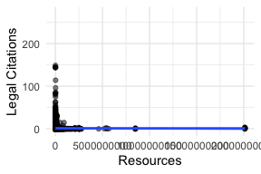

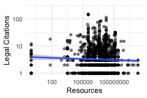

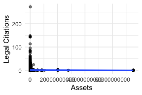

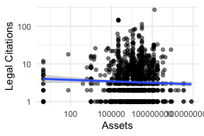

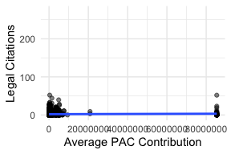

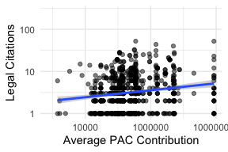

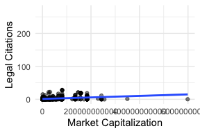

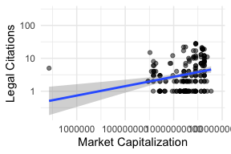

```r
# FDIC ASSTS
p <- b %>%
  ggplot() +
  aes(x = org_resources, # %>% log(),
      y = Total_Legal_Citations) +
  geom_jitter(alpha = .5) +
  geom_smooth(method = "lm"
  ) +
  labs(x = "Resources",
       y = "Legal Citations")

p

p +
  scale_y_log10() +
  scale_x_log10()

# nonprofits
p <- b %>%
  ggplot() +
  aes(x = assets,
      y = Total_Legal_Citations) +
  geom_jitter(alpha = .5) +
  geom_smooth(method = "lm"
  )+
  labs(x = "Assets",
       y = "Legal Citations")

p

p +
  scale_y_log10() +
  scale_x_log10()

# contribution
p <- b %>%
  ggplot() +
  aes(x = MeanContribAmount,
      y = Total_Legal_Citations) +
  geom_jitter(alpha = .5) +
  geom_smooth(method = "lm"
  ) +
  labs(x = "Average PAC Contribution",
       y = "Legal Citations")

p

p +
  scale_y_log10() +
  scale_x_log10()



p <- b %>%
  ggplot() +
  aes(x = marketcap2,
      y = Total_Legal_Citations) +
  geom_jitter(alpha = .5) +
  geom_smooth(method = "lm"
  ) +
  labs(x = "Market Capitalization",
       y = "Legal Citations")

p

p +
  scale_y_log10() +
  scale_x_log10()


# b %>% count(comment_agency, is.na( assets))

b %>% filter(Total_Legal_Citations>10,
             !is.na(org_name)) %>% dplyr::select(org_name,Total_Legal_Citations, comment_url, everything()) %>% arrange(-Total_Legal_Citations) %>% kablebox()
```

### Technical terms x assets

```r
t <- d %>% drop_na(dictionary_terms)


# FDIC ASSTS
p <- t %>%
  filter(!is.na(`FDIC_Institutions-bestMatch:ASSET`)) %>%
  ggplot() +
  aes(x = `FDIC_Institutions-bestMatch:ASSET`, # %>% log(),
      y = dictionary_terms ) +
  geom_point(alpha = .5) +
  geom_smooth(method = "lm"
  ) +
  labs(x = "Assets",
       y = "Legal and Technial Terms",
       title = "FDIC-Insured Banks")

p

p +
  scale_y_log10() +
  scale_x_log10()

t %>%
  filter(!is.na(`FDIC_Institutions-bestMatch:ASSET`), dictionary_terms == 0) %>%
  dplyr::select(org_name, everything() ) %>%
  kablebox()
```

| org_name | docket_id | comment_docket_count | comment_url | comment_agency | comment_org_name | comment_submitter_name | CIK_name | CreditUnions_name | FDIC_Institutions_name | FFIECInstitutions_name | SEC_Institutions_name | compustat_resources_name | nonprofits_resources_name | opensecrets_resources_jwVersion_name | best_match_name | best_match_score | best_match_type | FDIC_Institutions-bestMatch:ASSET | FDIC_Institutions-bestMatch:STNAME | CIK-bestMatch:marketcap | SEC_Institutions-bestMatch:Ticker | compustat_resources-bestMatch:marketcap | compustat_resources-bestMatch:naics | nonprofits_resources-bestMatch:assets | nonprofits_resources-bestMatch:revenue | nonprofits_resources-bestMatch:ein | opensecrets_resources_jwVersion-bestMatch:MeanContribAmountPerYearContributed | opensecrets_resources_jwVersion-bestMatch:TotalContribAmount | matches | … |
| --- | --- | --- | --- | --- | --- | --- | --- | --- | --- | --- | --- | --- | --- | --- | --- | --- | --- | --- | --- | --- | --- | --- | --- | --- | --- | --- | --- | --- | --- | --- |
| town country bank missouri | CFPB-2016-0038 | 1 | https://www.regulations.gov/comment/CFPB-2016-0038-1641 | CFPB | town country real estate | cindy collins | NA | NA | town country bank missouri | NA | NA | NA | NA | NA | town country bank missouri | 0.9234144 | FDIC | 26610 | Missouri | NA | NA | NA | NA | NA | NA | NA | NA | NA | town country bank missouri-FDIC | … |
| bank forest | CFPB-2016-0025 | 1 | https://www.regulations.gov/comment/CFPB-2016-0025-211822 | CFPB | bank forest | allen breland | NA | NA | bank forest | NA | NA | NA | NA | NA | bank forest | 1.0000000 | FDIC | 165509 | Mississippi | NA | NA | NA | NA | NA | NA | NA | NA | NA | bank forest-FDIC | … |
| bank forest | CFPB-2016-0025 | 1 | https://www.regulations.gov/comment/CFPB-2016-0025-211876 | CFPB | bank forest | allen breland | NA | NA | bank forest | NA | NA | NA | NA | NA | bank forest | 1.0000000 | FDIC | 165509 | Mississippi | NA | NA | NA | NA | NA | NA | NA | NA | NA | bank forest-FDIC | … |
| reliance bank | CFPB-2017-0021 | 1 | https://www.regulations.gov/comment/CFPB-2017-0021-0005 | CFPB | reliance bank | h barton buddy hann | NA | NA | reliance bank | NA | NA | NA | NA | NA | reliance bank | 1.0000000 | FDIC | 28637 | New York | NA | NA | NA | NA | NA | NA | NA | NA | NA | reliance bank-FDIC | … |
| citizens national bank | CFPB-2017-0021 | 1 | https://www.regulations.gov/comment/CFPB-2017-0021-0033 | CFPB | citizens national bank | della sanderford | NA | NA | citizens national bank | NA | NA | NA | NA | NA | citizens national bank | 1.0000000 | FDIC | 338179 | Connecticut | NA | NA | NA | NA | NA | NA | NA | NA | NA | citizens national bank-FDIC | … |
| first harrison bank | CFPB-2017-0021 | 1 | https://www.regulations.gov/comment/CFPB-2017-0021-0034 | CFPB | first harrison bank | jason pendleton | NA | NA | first harrison bank | NA | NA | NA | NA | NA | first harrison bank | 1.0000000 | FDIC | 760183 | Indiana | NA | NA | NA | NA | NA | NA | NA | NA | NA | first harrison bank-FDIC | … |
| university bank | CFPB-2017-0018 | 1 | https://www.regulations.gov/comment/CFPB-2017-0018-0004 | CFPB | university bank | teresa ferman | NA | NA | university bank | NA | NA | NA | NA | NA | university bank | 1.0000000 | FDIC | 65734 | Missouri | NA | NA | NA | NA | NA | NA | NA | NA | NA | university bank-FDIC | … |
| alden state bank | CFPB-2016-0025 | 1 | https://www.regulations.gov/comment/CFPB-2016-0025-208809 | CFPB | alden state bank | hilde neubauer | NA | NA | alden state bank | NA | NA | NA | NA | NA | alden state bank | 1.0000000 | FDIC | 309183 | New York | NA | NA | NA | NA | NA | NA | NA | NA | NA | alden state bank-FDIC | … |
| colonial savings fa | CFPB-2016-0038 | 1 | https://www.regulations.gov/comment/CFPB-2016-0038-1608 | CFPB | colonial savings bank fa | kish ivey | NA | NA | colonial savings fa | NA | NA | NA | NA | NA | colonial savings fa | 0.9987592 | FDIC | 136400 | Kansas | NA | NA | NA | NA | NA | NA | NA | NA | NA | colonial savings fa-FDIC | … |
| farmers merchants bank long beach | CFPB-2016-0038 | 1 | https://www.regulations.gov/comment/CFPB-2016-0038-1609 | CFPB | farmers merchants bank long beach | angela oganezova | NA | NA | farmers merchants bank long beach | NA | NA | NA | NA | NA | farmers merchants bank long beach | 1.0000000 | FDIC | 6834068 | California | NA | NA | NA | NA | NA | NA | NA | NA | NA | farmers merchants bank long beach-FDIC | … |
| first bank south | CFPB-2016-0038 | 1 | https://www.regulations.gov/comment/CFPB-2016-0038-1624 | CFPB | first south bank | sheila greer | NA | NA | first bank south | NA | NA | NA | NA | NA | first bank south | 1.0000000 | FDIC | 156890 | Illinois | NA | NA | NA | NA | NA | NA | NA | NA | NA | first bank south-FDIC | … |
| columbia bank | CFPB-2016-0038 | 1 | https://www.regulations.gov/comment/CFPB-2016-0038-1618 | CFPB | columbia bank | kathryn morris | NA | NA | columbia bank | NA | NA | NA | NA | NA | columbia bank | 1.0000000 | FDIC | 208384 | Florida | NA | NA | NA | NA | NA | NA | NA | NA | NA | columbia bank-FDIC | … |
| peoples intermountain bank | CFPB-2016-0025 | 1 | https://www.regulations.gov/comment/CFPB-2016-0025-148853 | CFPB | peoples intermountain bank | jay hunsaker | NA | NA | peoples intermountain bank | NA | NA | NA | NA | NA | peoples intermountain bank | 1.0000000 | FDIC | 1682347 | Utah | NA | NA | NA | NA | NA | NA | NA | NA | NA | peoples intermountain bank-FDIC | … |
| first federal arkansas fa | CFPB-2016-0025 | 1 | https://www.regulations.gov/comment/CFPB-2016-0025-186578 | CFPB | arkansas federal credit union | karyn davis | NA | NA | first federal arkansas fa | NA | NA | NA | NA | NA | first federal arkansas fa | 0.9702488 | FDIC | 1339075 | Arkansas | NA | NA | NA | NA | NA | NA | NA | NA | NA | first federal arkansas fa-FDIC | … |
| bryant bank | CFPB-2016-0025 | 1 | https://www.regulations.gov/comment/CFPB-2016-0025-185082 | CFPB | bryant bank | david long | NA | NA | bryant bank | NA | NA | NA | NA | NA | bryant bank | 1.0000000 | FDIC | 1501632 | Alabama | NA | NA | NA | NA | NA | NA | NA | NA | NA | bryant bank-FDIC | … |
| coastal bend national bank | CFPB-2016-0038 | 1 | https://www.regulations.gov/comment/CFPB-2016-0038-0027 | CFPB | keller williams coastal bend | char atnip | NA | NA | coastal bend national bank | NA | NA | NA | NA | NA | coastal bend national bank | 0.8568533 | FDIC | 38704 | Texas | NA | NA | NA | NA | NA | NA | NA | NA | NA | coastal bend national bank-FDIC | … |
| d l evans bank | CFPB-2016-0038 | 1 | https://www.regulations.gov/comment/CFPB-2016-0038-1324 | CFPB | d l evans bank | trevor matthews | NA | NA | d l evans bank | NA | NA | NA | NA | NA | d l evans bank | 1.0000000 | FDIC | 1312267 | Idaho | NA | NA | NA | NA | NA | NA | NA | NA | NA | d l evans bank-FDIC | … |
| american pacific bank | CFPB-2012-0028 | 1 | https://www.regulations.gov/comment/CFPB-2012-0028-2031 | CFPB | american pacific mortgage | marty allred | NA | NA | american pacific bank | NA | NA | NA | NA | NA | american pacific bank | 0.9459827 | FDIC | 124355 | Oregon | NA | NA | NA | NA | NA | NA | NA | NA | NA | american pacific bank-FDIC | … |
| citizens state bank | CFPB-2013-0002 | 1 | https://www.regulations.gov/comment/CFPB-2013-0002-0073 | CFPB | citizens state bank | kathy kruger | NA | NA | citizens state bank | NA | NA | NA | NA | NA | citizens state bank | 1.0000000 | FDIC | 261907 | Oklahoma | NA | NA | NA | NA | NA | NA | NA | NA | NA | citizens state bank-FDIC | … |
| guardian bank | CFPB-2013-0002 | 1 | https://www.regulations.gov/comment/CFPB-2013-0002-0475 | CFPB | guardian bank | pam horton | NA | NA | guardian bank | NA | NA | NA | NA | NA | guardian bank | 1.0000000 | FDIC | 73483 | Florida | NA | NA | NA | NA | NA | NA | NA | NA | NA | guardian bank-FDIC | … |
| united community bank | S7-08-13 | 1 | https://www.sec.gov/comments/s7-08-13/s70813-39.htm | SEC | united community bank | garland certain | NA | NA | united community bank | NA | NA | NA | NA | NA | united community bank | 1.0000000 | FDIC | 34537 | Kentucky | NA | NA | NA | NA | NA | NA | NA | NA | NA | united community bank-FDIC | … |
| bank san diego | S7-09-15 | 1 | https://www.sec.gov/comments/s7-09-15/s70915-4.htm | SEC | san diego | michael d berlin | NA | NA | bank san diego | NA | NA | NA | NA | NA | bank san diego | 1.0000000 | FDIC | 294277 | California | NA | NA | NA | NA | NA | NA | NA | NA | NA | bank san diego-FDIC | … |
| united republic bank | S7-42-10 | 1 | https://www.sec.gov/comments/s7-42-10/s74210-305.htm | SEC | united republic | semkae kilonzo | NA | NA | united republic bank | NA | NA | NA | NA | NA | united republic bank | 1.0000000 | FDIC | 108100 | Nebraska | NA | NA | NA | NA | NA | NA | NA | NA | NA | united republic bank-FDIC | … |
| reading cooperative bank | S7-14-11 | 1 | https://www.sec.gov/comments/s7-14-11/s71411-50.htm | SEC | reading cooperative bank | julieann m thurlow | NA | NA | reading cooperative bank | NA | NA | NA | NA | NA | reading cooperative bank | 1.0000000 | FDIC | 513042 | Massachusetts | NA | NA | NA | NA | NA | NA | NA | NA | NA | reading cooperative bank-FDIC | … |
| randolph savings bank | S7-45-10 | 1 | https://www.sec.gov/comments/s7-45-10/s74510-471.htm | SEC | randolph savings bank | liz turner | NA | NA | randolph savings bank | NA | NA | NA | NA | NA | randolph savings bank | 1.0000000 | FDIC | 482761 | Massachusetts | NA | NA | NA | NA | NA | NA | NA | NA | NA | randolph savings bank-FDIC | … |
| bank oldham county | S7-45-10 | 1 | https://www.sec.gov/comments/s7-45-10/s74510-326.htm | SEC | bank oldham county | stephen m norton | NA | NA | bank oldham county | NA | NA | NA | NA | NA | bank oldham county | 1.0000000 | FDIC | 143340 | Kentucky | NA | NA | NA | NA | NA | NA | NA | NA | NA | bank oldham county-FDIC | … |
| granite savings bank | S7-45-10 | 1 | https://www.sec.gov/comments/s7-45-10/s74510-210.htm | SEC | granite savings bank | norman s seppala | NA | NA | granite savings bank | NA | NA | NA | NA | NA | granite savings bank | 1.0000000 | FDIC | 64975 | Massachusetts | NA | NA | NA | NA | NA | NA | NA | NA | NA | granite savings bank-FDIC | … |
| greenfield cooperative bank | S7-45-10 | 1 | https://www.sec.gov/comments/s7-45-10/s74510-209.htm | SEC | greenfield cooperative bank | anthony j worden | NA | NA | greenfield cooperative bank | NA | NA | NA | NA | NA | greenfield cooperative bank | 1.0000000 | FDIC | 578831 | Massachusetts | NA | NA | NA | NA | NA | NA | NA | NA | NA | greenfield cooperative bank-FDIC | … |
| greenfield cooperative bank | S7-45-10 | 1 | https://www.sec.gov/comments/s7-45-10/s74510-207.htm | SEC | greenfield cooperative bank | david g ahearn | NA | NA | greenfield cooperative bank | NA | NA | NA | NA | NA | greenfield cooperative bank | 1.0000000 | FDIC | 578831 | Massachusetts | NA | NA | NA | NA | NA | NA | NA | NA | NA | greenfield cooperative bank-FDIC | … |
| bank elk river | S7-45-10 | 1 | https://www.sec.gov/comments/s7-45-10/s74510-206.htm | SEC | city elk river | tim simon | NA | NA | bank elk river | NA | NA | NA | NA | NA | bank elk river | 0.9895928 | FDIC | 408374 | Minnesota | NA | NA | NA | NA | NA | NA | NA | NA | NA | bank elk river-FDIC | … |
| greenfield cooperative bank | S7-45-10 | 1 | https://www.sec.gov/comments/s7-45-10/s74510-183.htm | SEC | greenfield cooperative bank | eric marsh | NA | NA | greenfield cooperative bank | NA | NA | NA | NA | NA | greenfield cooperative bank | 1.0000000 | FDIC | 578831 | Massachusetts | NA | NA | NA | NA | NA | NA | NA | NA | NA | greenfield cooperative bank-FDIC | … |
| first national bank bastrop | S7-45-10 | 1 | https://www.sec.gov/comments/s7-45-10/s74510-152.htm | SEC | first national bank bastrop | reid sharp | NA | NA | first national bank bastrop | NA | NA | NA | NA | NA | first national bank bastrop | 1.0000000 | FDIC | 532024 | Texas | NA | NA | NA | NA | NA | NA | NA | NA | NA | first national bank bastrop-FDIC | … |
| community bank | R-1443_V1 | 1 | https://www.federalreserve.gov/SECRS/2013/January/20130129/R-1443/R-1443_110512_110579_355661550171_1.pdf | FRS | community bank | david hughes | NA | NA | community bank | NA | NA | NA | NA | NA | community bank | 1.0000000 | FDIC | 569546 | Alabama | NA | NA | NA | NA | NA | NA | NA | NA | NA | community bank-FDIC | … |
| community bank | R-1443_V1 | 1 | https://www.federalreserve.gov/SECRS/2013/January/20130129/R-1443/R-1443_110512_110580_355662018945_1.pdf | FRS | community bank | david j washer | NA | NA | community bank | NA | NA | NA | NA | NA | community bank | 1.0000000 | FDIC | 569546 | Alabama | NA | NA | NA | NA | NA | NA | NA | NA | NA | community bank-FDIC | … |
| community bank | R-1443_V1 | 1 | https://www.federalreserve.gov/SECRS/2013/January/20130129/R-1443/R-1443_110512_110581_355662331461_1.pdf | FRS | community bank | coast | NA | NA | community bank | NA | NA | NA | NA | NA | community bank | 1.0000000 | FDIC | 569546 | Alabama | NA | NA | NA | NA | NA | NA | NA | NA | NA | community bank-FDIC | … |
| compass bank | CFTC-2012-0102 | 1 | https://comments.cftc.gov/PublicComments/ViewComment.aspx?id=58869 | CFTC | compass bank | brian goodrich | NA | NA | compass bank | NA | NA | NA | NA | NA | compass bank | 1.0000000 | FDIC | 83988195 | Alabama | NA | NA | NA | NA | NA | NA | NA | NA | NA | compass bank-FDIC | … |
| regions bank | CFTC-2012-0058 | 1 | https://comments.cftc.gov/PublicComments/ViewExParte.aspx?id=338 | CFTC | regions bank | ex parte communication | NA | NA | regions bank | NA | NA | NA | NA | NA | regions bank | 1.0000000 | FDIC | 123636430 | Alabama | NA | NA | NA | NA | NA | NA | NA | NA | NA | regions bank-FDIC | … |
| bank webster | CFTC-2012-0058 | 1 | https://comments.cftc.gov/PublicComments/ViewExParte.aspx?id=317 | CFTC | webster bank | ex parte communication | NA | NA | bank webster | NA | NA | NA | NA | NA | bank webster | 1.0000000 | FDIC | 4242 | Georgia | NA | NA | NA | NA | NA | NA | NA | NA | NA | bank webster-FDIC | … |
| first national bank in miles city | CFTC-2012-0019 | 1 | https://comments.cftc.gov/PublicComments/ViewComment.aspx?id=57329 | CFTC | stockman bank montana miles city montana | bill bickle | NA | NA | first national bank in miles city | NA | NA | NA | NA | NA | first national bank in miles city | 0.6502750 | FDIC | 72868 | Montana | NA | NA | NA | NA | NA | NA | NA | NA | NA | first national bank in miles city-FDIC | … |
| goldman sachs bank usa | CFTC-2012-0058 | 1 | https://comments.cftc.gov/PublicComments/ViewExParte.aspx?id=884 | CFTC | goldman sachs bank usa | ex parte communication | NA | NA | goldman sachs bank usa | NA | NA | NA | NA | NA | goldman sachs bank usa | 1.0000000 | FDIC | 156156000 | New York | NA | NA | NA | NA | NA | NA | NA | NA | NA | goldman sachs bank usa-FDIC | … |
| allied cypress bank | CFTC-2012-0058 | 1 | https://comments.cftc.gov/PublicComments/ViewExParte.aspx?id=223 | CFTC | cypress group cypress | ex parte communication | NA | NA | allied cypress bank | NA | NA | NA | NA | NA | allied cypress bank | 0.9808917 | FDIC | 128701 | Texas | NA | NA | NA | NA | NA | NA | NA | NA | NA | allied cypress bank-FDIC | … |
| peoples bank | CFTC-2012-0058 | 1 | https://comments.cftc.gov/PublicComments/ViewComment.aspx?id=27774 | CFTC | peoples bank | jack hartings | NA | NA | peoples bank | NA | NA | NA | NA | NA | peoples bank | 1.0000000 | FDIC | 11896 | Alabama | NA | NA | NA | NA | NA | NA | NA | NA | NA | peoples bank-FDIC | … |
| united oklahoma bank | CFTC-2012-0058 | 1 | https://comments.cftc.gov/PublicComments/ViewExParte.aspx?id=238 | CFTC | bank oklahoma | ex parte communication | NA | NA | united oklahoma bank | NA | NA | NA | NA | NA | united oklahoma bank | 1.0000000 | FDIC | 171925 | Oklahoma | NA | NA | NA | NA | NA | NA | NA | NA | NA | united oklahoma bank-FDIC | … |
| capital one fsb | CFTC-2012-0058 | 1 | https://comments.cftc.gov/PublicComments/ViewExParte.aspx?id=243 | CFTC | capital one na | ex parte communication | NA | NA | capital one fsb | NA | NA | NA | NA | NA | capital one fsb | 0.9792454 | FDIC | 17487074 | Virginia | NA | NA | NA | NA | NA | NA | NA | NA | NA | capital one fsb-FDIC | … |
| privatebank trust | CFTC-2010-0196 | 1 | https://comments.cftc.gov/PublicComments/ViewExParte.aspx?id=417 | CFTC | privatebank trust | ex parte communication | NA | NA | privatebank trust | NA | NA | NA | NA | NA | privatebank trust | 1.0000000 | FDIC | 20401001 | Illinois | NA | NA | NA | NA | NA | NA | NA | NA | NA | privatebank trust-FDIC | … |
| vectra bank colorado national association | CFTC-2013-0107 | 1 | https://comments.cftc.gov/PublicComments/ViewExParte.aspx?id=1013 | CFTC | copperwood asset management lp copperwood vectra capital llc vectra | ex parte communication | NA | NA | vectra bank colorado national association | NA | NA | NA | NA | NA | vectra bank colorado national association | 0.5954048 | FDIC | 3317609 | New Mexico | NA | NA | NA | NA | NA | NA | NA | NA | NA | vectra bank colorado national association-FDIC | … |
| farmers national bank | CFTC-2013-0107 | 1 | https://comments.cftc.gov/PublicComments/ViewComment.aspx?id=59661 | CFTC | national farmers organization | michael miller | NA | NA | farmers national bank | NA | NA | NA | NA | NA | farmers national bank | 0.9931716 | FDIC | 86960 | Kentucky | NA | NA | NA | NA | NA | NA | NA | NA | NA | farmers national bank-FDIC | … |
| great plains national bank | CFTC-2013-0107 | 1 | https://comments.cftc.gov/PublicComments/ViewComment.aspx?id=59559 | CFTC | great plains national bank | terry shelby | NA | NA | great plains national bank | NA | NA | NA | NA | NA | great plains national bank | 1.0000000 | FDIC | 217138 | North Dakota | NA | NA | NA | NA | NA | NA | NA | NA | NA | great plains national bank-FDIC | … |
| huntington bank martinsburg national association | CFTC-2011-0049 | 1 | https://comments.cftc.gov/PublicComments/ViewExParte.aspx?id=1187 | CFTC | american bankers association bbt corporation bok financial comerica bank huntington national bank regions bank | ex parte communication | NA | NA | huntington bank martinsburg national association | NA | NA | NA | NA | NA | huntington bank martinsburg national association | 0.6668734 | FDIC | 136447 | West Virginia | NA | NA | NA | NA | NA | NA | NA | NA | NA | huntington bank martinsburg national association-FDIC | … |
| jp morgan delaware | CFTC-2011-0049 | 1 | https://comments.cftc.gov/PublicComments/ViewExParte.aspx?id=1166 | CFTC | jp morgan | ex parte communication | NA | NA | jp morgan delaware | NA | NA | NA | NA | NA | jp morgan delaware | 1.0000000 | FDIC | 2812803 | Delaware | NA | NA | NA | NA | NA | NA | NA | NA | NA | jp morgan delaware-FDIC | … |
| bank new york mellon trust company national association | CFTC-2011-0049 | 1 | https://comments.cftc.gov/PublicComments/ViewExParte.aspx?id=997 | CFTC | state street bank new york mellon northern trust | ex parte communication | NA | NA | bank new york mellon trust company national association | NA | NA | NA | NA | NA | bank new york mellon trust company national association | 0.5018417 | FDIC | 2131826 | California | NA | NA | NA | NA | NA | NA | NA | NA | NA | bank new york mellon trust company national association-FDIC | … |
| jp morgan delaware | CFTC-2011-0049 | 1 | https://comments.cftc.gov/PublicComments/ViewExParte.aspx?id=1095 | CFTC | jp morgan | ex parte communication | NA | NA | jp morgan delaware | NA | NA | NA | NA | NA | jp morgan delaware | 1.0000000 | FDIC | 2812803 | Delaware | NA | NA | NA | NA | NA | NA | NA | NA | NA | jp morgan delaware-FDIC | … |
| firstmerit bank fsb | CFTC-2010-0153 | 1 | https://comments.cftc.gov/PublicComments/ViewComment.aspx?id=50300 | CFTC | firstmerit bank | jason ebert | NA | NA | firstmerit bank fsb | NA | NA | NA | NA | NA | firstmerit bank fsb | 1.0000000 | FDIC | 119633 | Florida | NA | NA | NA | NA | NA | NA | NA | NA | NA | firstmerit bank fsb-FDIC | … |
| regional bank | CFTC-2010-0153 | 1 | https://comments.cftc.gov/PublicComments/ViewComment.aspx?id=27084 | CFTC | regional bank | corey means | NA | NA | regional bank | NA | NA | NA | NA | NA | regional bank | 1.0000000 | FDIC | 251274 | Indiana | NA | NA | NA | NA | NA | NA | NA | NA | NA | regional bank-FDIC | … |
| regional bank | CFTC-2010-0158 | 1 | https://comments.cftc.gov/PublicComments/ViewComment.aspx?id=26499 | CFTC | regional bank | corey means | NA | NA | regional bank | NA | NA | NA | NA | NA | regional bank | 1.0000000 | FDIC | 251274 | Indiana | NA | NA | NA | NA | NA | NA | NA | NA | NA | regional bank-FDIC | … |
| firstmerit bank fsb | CFTC-2011-0013 | 1 | https://comments.cftc.gov/PublicComments/ViewComment.aspx?id=50301 | CFTC | firstmerit bank | jason ebert | NA | NA | firstmerit bank fsb | NA | NA | NA | NA | NA | firstmerit bank fsb | 1.0000000 | FDIC | 119633 | Florida | NA | NA | NA | NA | NA | NA | NA | NA | NA | firstmerit bank fsb-FDIC | … |
| oxford university bank | CFTC-2011-0013 | 1 | https://comments.cftc.gov/PublicComments/ViewComment.aspx?id=33431 | CFTC | university oxford | simon driscoll | NA | NA | oxford university bank | NA | NA | NA | NA | NA | oxford university bank | 1.0000000 | FDIC | 131837 | Mississippi | NA | NA | NA | NA | NA | NA | NA | NA | NA | oxford university bank-FDIC | … |
| silicon valley bank | CFTC-2010-0115 | 1 | https://comments.cftc.gov/PublicComments/ViewComment.aspx?id=4816 | CFTC | silicon valley forex | lawrence pingree | NA | NA | silicon valley bank | NA | NA | NA | NA | NA | silicon valley bank | 0.8349614 | FDIC | 45813986 | California | NA | NA | NA | NA | NA | NA | NA | NA | NA | silicon valley bank-FDIC | … |
| frost bank | CFTC-2011-0013 | 1 | https://comments.cftc.gov/PublicComments/ViewComment.aspx?id=28389 | CFTC | frost bank | tim mccormick | NA | NA | frost bank | NA | NA | NA | NA | NA | frost bank | 1.0000000 | FDIC | 30552661 | Texas | NA | NA | NA | NA | NA | NA | NA | NA | NA | frost bank-FDIC | … |
| united republic bank | CFTC-2011-0013 | 1 | https://comments.cftc.gov/PublicComments/ViewComment.aspx?id=28135 | CFTC | republic united states | special victim | NA | NA | united republic bank | NA | NA | NA | NA | NA | united republic bank | 0.8960139 | FDIC | 108100 | Nebraska | NA | NA | NA | NA | NA | NA | NA | NA | NA | united republic bank-FDIC | … |
| regional bank | CFTC-2011-0013 | 1 | https://comments.cftc.gov/PublicComments/ViewComment.aspx?id=56717 | CFTC | regional bank | corey means | NA | NA | regional bank | NA | NA | NA | NA | NA | regional bank | 1.0000000 | FDIC | 251274 | Indiana | NA | NA | NA | NA | NA | NA | NA | NA | NA | regional bank-FDIC | … |

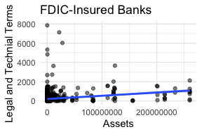

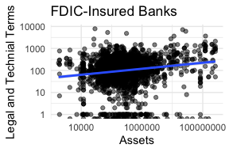

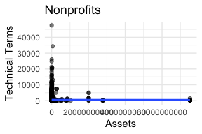

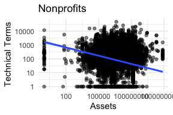

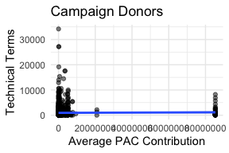

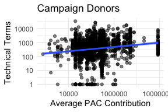

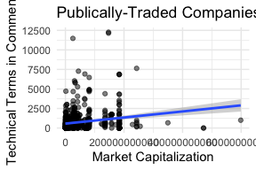

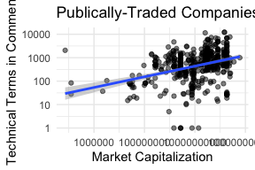

```r
# nonprofits
p <- t %>%
  filter(!is.na(assets)) %>%
  ggplot() +
  aes(x = assets,
      y = dictionary_terms) +
  geom_jitter(alpha = .5) +
  geom_smooth(method = "lm"
  ) +
  labs(x = "Assets",
       y = "Technical Terms",
       title = "Nonprofits")

p

p +
  scale_y_log10() +
  scale_x_log10()

# contribution
p <- t %>%
  filter(!is.na(MeanContribAmount)) %>%
  ggplot() +
  aes(x = MeanContribAmount,
      y = dictionary_terms) +
  geom_jitter(alpha = .5) +
  geom_smooth(method = "lm"
  ) +
  labs(x = "Average PAC Contribution",
       y = "Technical Terms",
       title = "Campaign Donors")

p

p +
  scale_y_log10() +
  scale_x_log10()


p <- t %>%
  filter(!is.na(marketcap2)) %>%
  ggplot() +
  aes(x = marketcap2,
      y = dictionary_terms) +
  geom_jitter(alpha = .5) +
  geom_smooth(method = "lm"
  ) +
  labs(x = "Market Capitalization",
       y = "Technical Terms in Comment",
       title = "Publically-Traded Companies")

p

p +
  scale_y_log10() +
  scale_x_log10()
```

## Efficacy x assets

```r
e <- d %>% drop_na(efficacy)


# FDIC ASSTS
p <- e %>%
  filter(!is.na(`FDIC_Institutions-bestMatch:ASSET`)) %>%
  ggplot() +
  aes(x = `FDIC_Institutions-bestMatch:ASSET`, # %>% log(),
      y = efficacy ) +
  geom_point(alpha = .5) +
  geom_smooth(method = "lm"
  ) +
  labs(x = "Assets",
       y = "Number of Words in Comment\nAdded to Final Rule",
       title = "FDIC-Insured Banks")

p

p +
  scale_y_log10() +
  scale_x_log10()


e %>%
  filter(!is.na(`FDIC_Institutions-bestMatch:ASSET`), efficacy == 0) %>%
  dplyr::select(org_name, everything() ) %>%
  kablebox()
```

| org_name | docket_id | comment_docket_count | comment_url | comment_agency | comment_org_name | comment_submitter_name | CIK_name | CreditUnions_name | FDIC_Institutions_name | FFIECInstitutions_name | SEC_Institutions_name | compustat_resources_name | nonprofits_resources_name | opensecrets_resources_jwVersion_name | best_match_name | best_match_score | best_match_type | FDIC_Institutions-bestMatch:ASSET | FDIC_Institutions-bestMatch:STNAME | CIK-bestMatch:marketcap | SEC_Institutions-bestMatch:Ticker | compustat_resources-bestMatch:marketcap | compustat_resources-bestMatch:naics | nonprofits_resources-bestMatch:assets | nonprofits_resources-bestMatch:revenue | nonprofits_resources-bestMatch:ein | opensecrets_resources_jwVersion-bestMatch:MeanContribAmountPerYearContributed | opensecrets_resources_jwVersion-bestMatch:TotalContribAmount | matches | … |
| --- | --- | --- | --- | --- | --- | --- | --- | --- | --- | --- | --- | --- | --- | --- | --- | --- | --- | --- | --- | --- | --- | --- | --- | --- | --- | --- | --- | --- | --- | --- |
| pine belt federal savings loan association | CFPB-2016-0025 | 1 | https://www.regulations.gov/comment/CFPB-2016-0025-148772 | CFPB | pine federal credit union | terry tucker | NA | NA | pine belt federal savings loan association | NA | NA | NA | NA | NA | pine belt federal savings loan association | 0.9789054 | FDIC | 72626 | Mississippi | NA | NA | NA | NA | NA | NA | NA | NA | NA | pine belt federal savings loan association-FDIC | … |
| pine belt federal savings loan association | CFPB-2016-0025 | 1 | https://www.regulations.gov/comment/CFPB-2016-0025-148771 | CFPB | pine federal credit union | terry tucker | NA | NA | pine belt federal savings loan association | NA | NA | NA | NA | NA | pine belt federal savings loan association | 0.9789054 | FDIC | 72626 | Mississippi | NA | NA | NA | NA | NA | NA | NA | NA | NA | pine belt federal savings loan association-FDIC | … |
| pine belt federal savings loan association | CFPB-2016-0025 | 1 | https://www.regulations.gov/comment/CFPB-2016-0025-148775 | CFPB | pine federal credit union | terry tucker | NA | NA | pine belt federal savings loan association | NA | NA | NA | NA | NA | pine belt federal savings loan association | 0.9789054 | FDIC | 72626 | Mississippi | NA | NA | NA | NA | NA | NA | NA | NA | NA | pine belt federal savings loan association-FDIC | … |
| pine belt federal savings loan association | CFPB-2016-0025 | 1 | https://www.regulations.gov/comment/CFPB-2016-0025-148773 | CFPB | pine federal credit union | terry tucker | NA | NA | pine belt federal savings loan association | NA | NA | NA | NA | NA | pine belt federal savings loan association | 0.9789054 | FDIC | 72626 | Mississippi | NA | NA | NA | NA | NA | NA | NA | NA | NA | pine belt federal savings loan association-FDIC | … |
| pine belt federal savings loan association | CFPB-2016-0025 | 1 | https://www.regulations.gov/comment/CFPB-2016-0025-148774 | CFPB | pine federal credit union | terry tucker | NA | NA | pine belt federal savings loan association | NA | NA | NA | NA | NA | pine belt federal savings loan association | 0.9789054 | FDIC | 72626 | Mississippi | NA | NA | NA | NA | NA | NA | NA | NA | NA | pine belt federal savings loan association-FDIC | … |
| first american savings loan association | CFPB-2016-0025 | 1 | https://www.regulations.gov/comment/CFPB-2016-0025-199026 | CFPB | first american loan | first american loan first american loan | NA | NA | first american savings loan association | NA | NA | NA | NA | NA | first american savings loan association | 1.0000000 | FDIC | 34249 | Illinois | NA | NA | NA | NA | NA | NA | NA | NA | NA | first american savings loan association-FDIC | … |
| progress bank | R-1438_V1 | 1 | https://www.federalreserve.gov/SECRS/2014/March/20140307/R-1483/R-1483_021314_112095_541706233068_1.pdf | FRS | progress bank | james d brown | NA | NA | progress bank | NA | NA | NA | NA | NA | progress bank | 1.0000000 | FDIC | 1160733 | Pennsylvania | NA | NA | NA | NA | NA | NA | NA | NA | NA | progress bank-FDIC | … |
| sound community bank | R-1438_V1 | 1 | https://www.federalreserve.gov/SECRS/2014/March/20140325/R-1483/R-1483_032514_112152_593835800716_1.pdf | FRS | sound community bank | gary l boman | NA | NA | sound community bank | NA | NA | NA | NA | NA | sound community bank | 1.0000000 | FDIC | 574740 | Washington | NA | NA | NA | NA | NA | NA | NA | NA | NA | sound community bank-FDIC | … |
| progress bank | R-1482_V1 | 1 | https://www.federalreserve.gov/SECRS/2014/March/20140307/R-1482/R-1483_021314_112095_541706233068_1.pdf | FRS | progress bank | james d brown | NA | NA | progress bank | NA | NA | NA | NA | NA | progress bank | 1.0000000 | FDIC | 1160733 | Pennsylvania | NA | NA | NA | NA | NA | NA | NA | NA | NA | progress bank-FDIC | … |
| sound community bank | R-1482_V1 | 1 | https://www.federalreserve.gov/SECRS/2014/March/20140325/R-1482/R-1482_032514_112149_593395313546_1.pdf | FRS | sound community bank | gary l boman | NA | NA | sound community bank | NA | NA | NA | NA | NA | sound community bank | 1.0000000 | FDIC | 574740 | Washington | NA | NA | NA | NA | NA | NA | NA | NA | NA | sound community bank-FDIC | … |

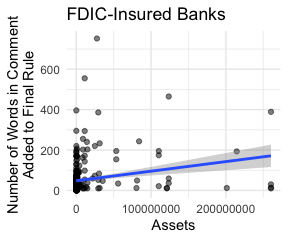

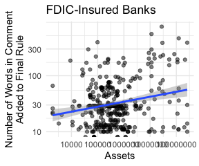

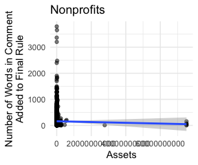

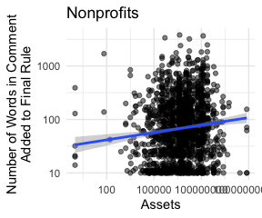

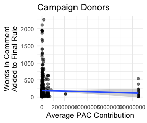

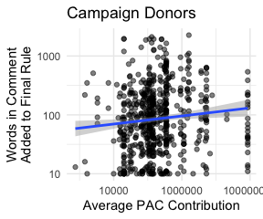

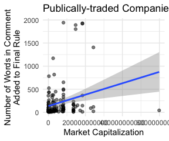

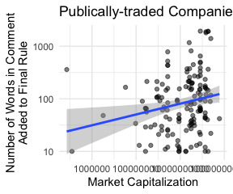

```r
# nonprofits
p <- e %>%
  filter(!is.na(assets)) %>%
  ggplot() +
  aes(x = assets,
      y = efficacy) +
  geom_jitter(alpha = .5) +
  geom_smooth(method = "lm"
  ) +
  labs(x = "Assets",
       y = "Number of Words in Comment\nAdded to Final Rule",
       title = "Nonprofits")

p

p +
  scale_y_log10() +
  scale_x_log10()


# contribution
p <- e %>%
  filter(!is.na(MeanContribAmount)) %>%
  ggplot() +
  aes(x = MeanContribAmount,
      y = efficacy) +
  geom_jitter(alpha = .5) +
  geom_smooth(method = "lm"
  ) +
  labs(x = "Average PAC Contribution",
       y = "Words in Comment\nAdded to Final Rule",
       title = "Campaign Donors")

p

p +
  scale_y_log10() +
  scale_x_log10()

# market cap
p <- e %>%
  filter(!is.na(marketcap2)) %>%
  ggplot() +
  aes(x = marketcap2,
      y = efficacy) +
  geom_jitter(alpha = .5) +
  geom_smooth(method = "lm"
  ) +
  labs(x = "Market Capitalization",
       y = "Number of Words in Comment\nAdded to Final Rule",
       title = "Publically-traded Companies")

p

p +
  scale_y_log10() +
  scale_x_log10()
```

## Efficacy x sophistication

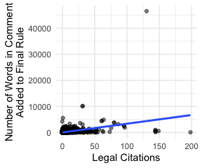

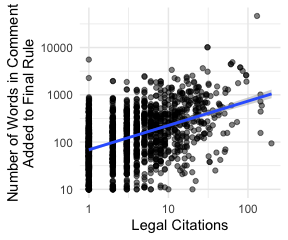

```r
p <- e %>%
  ggplot() +
  aes(x = Total_Legal_Citations,
      y = efficacy) +
  geom_jitter(alpha = .5) +
  geom_smooth(method = "lm"
  ) +
  labs(x = "Legal Citations",
       y = "Number of Words in Comment\nAdded to Final Rule")

p

p +
  scale_y_log10() +
  scale_x_log10()
```

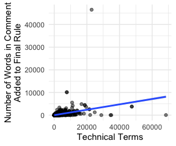

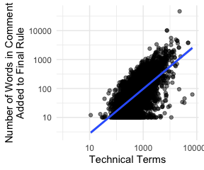

```r
p <- e %>%
  #filter(!is.na(marketcap2)) %>%
  ggplot() +
  aes(x = dictionary_terms,
      y = efficacy) +
  geom_jitter(alpha = .5) +
  geom_smooth(method = "lm"
  ) +
  labs(x = "Technical Terms",
       y = "Number of Words in Comment\nAdded to Final Rule")

p

p +
  scale_y_log10() +
  scale_x_log10()
```

# Regressions

```r
# change knitr defaults
knitr::opts_chunk$set(fig.show="show",
                      fig.height=1,
                      fig.width=5,
                      out.width = "80%")

# rename coeficients for tables and plots
cm = c("ASSET" = "Assets",
       "ASSETS" = "Assets (Hundreds of Millions)",
       "Assets" = "Assets (Billions)",
       "assets" = "Assets",
       "marketcap2" = "Market Capitalization",
       "Class SM" = "State Bank",
       "Class SB" = "Savings Bank",
       "Class SA" = "Savings Association",
       "Class NM" = "Commercial Bank",
       "ASSETS:Class SM" = "Assets x State Bank",
       "ASSETS:Class SB" = "Assets x Savings Bank",
       "ASSETS:Class SA" = "Assets x Savings Association",
       "ASSETS:Class NM" = "Assets x Commercial Bank",
       "dictionary_terms" = "Technical Terms",
       "Total_Legal_Citations" = "Legal Citations")

gm = list("Num.Obs." = "Number of Comments",
       "R2" = "R2",
       "AIC" = "AIC")
```

## Sophistication

> NOTE: I’m using OLS for now but will switch to Poisson or Negative Binomial.

### Bluebook

```r
b %>% drop_na(assets, Total_Legal_Citations) %>%
  arrange(-Total_Legal_Citations) %>%
  dplyr::select(assets, Total_Legal_Citations, comment_url) %>%
  kablebox()
```

| assets | Total_Legal_Citations | comment_url |
| --- | --- | --- |
| 147073247 | 273 | https://www.regulations.gov/comment/CFPB-2016-0025-3913 |
| 325391 | 149 | https://www.regulations.gov/comment/CFPB-2014-0033-0164 |
| 325391 | 144 | https://www.regulations.gov/comment/CFPB-2011-0007-0006 |
| 325391 | 144 | https://www.regulations.gov/comment/CFPB-2011-0005-0008 |
| 325391 | 144 | https://www.regulations.gov/comment/CFPB-2011-0006-0006 |
| 325391 | 144 | https://www.regulations.gov/comment/CFPB-2011-0003-0009 |
| 17440205 | 114 | https://www.regulations.gov/comment/CFPB-2013-0033-0386 |
| 17440205 | 96 | https://www.regulations.gov/comment/CFPB-2016-0020-5831 |
| 17440205 | 86 | https://www.regulations.gov/comment/CFPB-2014-0033-0136 |
| 5568496 | 84 | https://www.sec.gov/comments/s7-03-13/s70313-335.pdf |
| 4642138 | 82 | https://www.regulations.gov/comment/CFPB-2013-0033-0393 |
| 4205309 | 80 | https://www.regulations.gov/comment/CFPB-2016-0025-154512 |
| 2522436 | 75 | https://www.regulations.gov/comment/CFPB-2016-0025-142779 |
| 281328 | 63 | https://www.regulations.gov/comment/CFPB-2014-0033-0056 |
| 3898749 | 62 | https://www.sec.gov/comments/s7-02-13/s70213-42.pdf |
| 10519520 | 57 | https://www.regulations.gov/comment/CFPB-2012-0028-2732 |
| 10519520 | 57 | https://www.regulations.gov/comment/CFPB-2012-0028-2782 |
| 3623362 | 56 | https://www.federalreserve.gov/SECRS/2013/May/20130517/R-1438/R-1438_043013_111113_555179652070_1.pdf |
| 10769784 | 52 | https://www.federalreserve.gov/SECRS/2011/March/20110303/R-1404/R-1404_022211_67462_559315186904_1.pdf |
| 325391 | 51 | https://www.regulations.gov/comment/CFPB-2014-0033-0144 |
| 17440205 | 49 | https://www.regulations.gov/comment/CFPB-2013-0002-0876 |
| 1163000 | 48 | https://www.regulations.gov/comment/CFPB-2014-0033-0117 |
| 3858601 | 45 | https://www.regulations.gov/comment/CFPB-2016-0020-4318 |
| 856845 | 45 | https://www.federalreserve.gov/SECRS/2012/September/20120912/R-1438/R-1438_043012_107236_478911121698_1.pdf |
| 1493337 | 45 | https://www.federalreserve.gov/SECRS/2011/September/20110913/R-1417/R-1417_072211_83618_591648672754_1.pdf |
| 325391 | 44 | https://www.regulations.gov/comment/CFPB-2012-0028-2765 |
| 325391 | 43 | https://www.regulations.gov/comment/CFPB-2014-0019-0256 |
| 325391 | 41 | https://www.regulations.gov/comment/CFPB-2013-0018-0274 |
| 17440205 | 40 | https://www.regulations.gov/comment/CFPB-2012-0034-0098 |
| 17440205 | 40 | https://www.regulations.gov/comment/CFPB-2012-0028-2811 |

[output cut: 270 more lines]

```r
rows <- tibble(
  term = c("Dependent Variable"),
  `1` = "Sophistication",
  `2` = "Sophistication",
  `3` = "Sophistication"
)

attr(rows, 'position') <- c(0)


mb_assets <- lm(Total_Legal_Citations ~ assets,  data = b  %>% mutate(assets = assets/10000000000))

mb_opensecrets <- glm(Total_Legal_Citations ~ MeanContribAmount,
           data = b %>% mutate(MeanContribAmount = MeanContribAmount/10000))

mb_marketcap <- glm(Total_Legal_Citations ~ marketcap2,
           data = b  %>% mutate(marketcap2 = marketcap2/10000000000))

models <- list(mb_assets, mb_opensecrets, mb_marketcap)

modelsummary(models)
```

|  | Model 1 | Model 2 | Model 3 |
| --- | --- | --- | --- |
| Dependent Variable | Sophistication | Sophistication | Sophistication |
| Assets | −0.196 |  |  |
|  | (0.195) |  |  |
| MeanContribAmount |  | 0.000* |  |
|  |  | (0.000) |  |
| Market Capitalization |  |  | 0.229*** |
|  |  |  | (0.030) |
| Num.Obs. | 7987 | 2032 | 492 |
| R2 | 0.000 |  |  |
| R2 Adj. | 0.000 |  |  |
| AIC | 53036.1 | 12042.2 | 2903.5 |
| BIC | 53057.1 | 12059.1 | 2916.1 |
| Log.Lik. | −26515.057 | −6018.106 | −1448.758 |
| F | 1.017 |  |  |
| RMSE | 6.69 | 4.68 | 4.61 |

+ p < 0.1, * p < 0.05, ** p < 0.01, *** p < 0.001

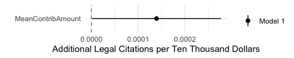

```r
modelplot(mb_opensecrets) +
  labs(x = "Additional Legal Citations per Ten Thousand Dollars")
```

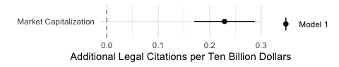

```r
modelplot(mb_marketcap) +
  labs(x = "Additional Legal Citations per Ten Billion Dollars")
```

### Technical Terms

These models have the prefix `mt_`. The dependent variable is a count of technical terms per comment.

```r
t %>% drop_na(assets, dictionary_terms) %>%
  arrange(-dictionary_terms) %>%
  dplyr::select(assets, dictionary_terms, comment_url) %>%
  kablebox()
```

| assets | dictionary_terms | comment_url |
| --- | --- | --- |
| 4205309 | 47531 | https://www.regulations.gov/comment/CFPB-2016-0025-154512 |
| 607993699 | 34328 | https://comments.cftc.gov/PublicComments/ViewComment.aspx?id=59278 |
| 17440205 | 26080 | https://www.regulations.gov/comment/CFPB-2013-0033-0386 |
| 3623362 | 24811 | https://www.federalreserve.gov/SECRS/2013/May/20130517/R-1438/R-1438_043013_111113_555179652070_1.pdf |
| 350942 | 21388 | https://www.sec.gov/comments/s7-08-10/s70810-60.pdf |
| 239942508 | 20708 | https://www.sec.gov/comments/s7-14-11/s71411-133.pdf |
| 239942508 | 20691 | https://www.federalreserve.gov/SECRS/2012/June/20120607/R-1411/R-1411_050212_107284_511638451448_1.pdf |
| 4642138 | 20190 | https://www.regulations.gov/comment/CFPB-2013-0033-0393 |
| 129958383 | 19544 | https://www.federalreserve.gov/SECRS/2012/December/20121206/R-1442/R-1442_102212_110014_386243203248_1.pdf |
| 2522436 | 18202 | https://www.regulations.gov/comment/CFPB-2016-0025-143313 |
| 325391 | 16402 | https://www.regulations.gov/comment/CFPB-2014-0033-0164 |
| 147073247 | 16394 | https://www.regulations.gov/comment/CFPB-2016-0025-3913 |
| 14549 | 15579 | https://www.federalreserve.gov/SECRS/2016/August/20160812/R-1536/R-1536_071816_130347_536946206490_1.pdf |
| 41801 | 15569 | https://www.regulations.gov/comment/CFPB-2016-0020-4256 |
| 325391 | 14287 | https://www.regulations.gov/comment/CFPB-2013-0018-0274 |
| 17440205 | 14194 | https://www.regulations.gov/comment/CFPB-2016-0020-5831 |
| 792265099 | 12891 | https://www.regulations.gov/comment/CFPB-2016-0025-142716 |
| 325391 | 12826 | https://www.regulations.gov/comment/CFPB-2013-0010-0072 |
| 56014529 | 12291 | https://www.sec.gov/comments/s7-09-15/s70915-37.pdf |
| 2522436 | 11944 | https://www.regulations.gov/comment/CFPB-2016-0025-142779 |
| 1 | 11752 | https://www.sec.gov/comments/s7-14-11/s71411-448.pdf |
| 10519520 | 11724 | https://www.regulations.gov/comment/CFPB-2012-0028-2732 |
| 10519520 | 11724 | https://www.regulations.gov/comment/CFPB-2012-0028-2782 |
| 1493337 | 11318 | https://www.regulations.gov/comment/CFPB-2012-0034-0146 |
| 1493337 | 11318 | https://www.regulations.gov/comment/CFPB-2012-0033-0162 |
| 287090 | 11217 | https://www.sec.gov/comments/s7-40-10/s74010-566.pdf |
| 162861 | 11132 | https://www.regulations.gov/comment/CFPB-2013-0033-0381 |
| 17440205 | 10933 | https://www.regulations.gov/comment/CFPB-2014-0033-0136 |
| 239942508 | 10907 | https://www.sec.gov/comments/s7-12-15/s71215-67.pdf |
| 129958383 | 10420 | https://www.regulations.gov/comment/CFPB-2012-0028-2673 |

[output cut: 270 more lines]

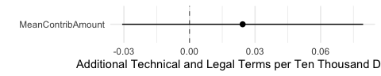

```r
# broken out by org type

mt_assets <- lm(dictionary_terms ~ assets,
           data = t  %>% mutate(assets = assets/10000000000))

mt_opensecrets <- glm(dictionary_terms ~ MeanContribAmount,
           data = t %>% mutate(MeanContribAmount = MeanContribAmount/10000))

mt_marketcap <- glm(dictionary_terms ~ marketcap2,
           data = t  %>% mutate(marketcap2 = marketcap2/10000000000))

models <- list(mt_assets, mt_marketcap)

# FIXME
# modelsummary(models)

modelplot( mt_opensecrets) + theme(legend.position = "none") +
  labs(x = "Additional Technical and Legal Terms per Ten Thousand Dollars")
```

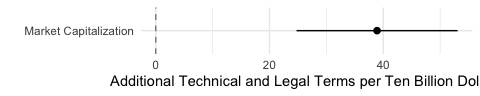

```r
modelplot(mt_marketcap) + theme(legend.position = "none") +
  labs(x = "Additional Technical and Legal Terms per Ten Billion Dollars")
```